# Project I - Airbnb Boston & Seattle Data Analysis

### Project I - Airbnb Boston & Seattle Data Analysis

For this project, I will follow the CRISP-DM process to create a blog post and Github repository to begin building a data science portfolio of my own.

1. Business Understanding & Data Understanding
   1. Business Understadning
   2. Business Questions
   3. Data Exploration
   4. Data Understadning
2. Data Preparation
   1. Calander Data Wrangling & Cleaning
   2. Listing Data Wrangling & Cleaning
3. Modelling & Evaluation
   1. Question 1
   2. Question 2
   3. Question 3
4. Next Step: Deployment & Communication

#### Part I: Business Understanding & Data Understanding

In `Part I` of the Airbnb Project, I would like to first check the dataset to get a glimpse of the information provided, and then come up with three business questions that I am interested in. Following the questions, I will dig a bit deeper into the dataset.

##### Business Understanding

```python
#import packages
import numpy as np
import pandas as pd
import matplotlib.pyplot as plt
plt.style.use("seaborn")
%matplotlib inline
import seaborn as sns
from IPython.display import display

from sklearn.linear_model import LinearRegression
from sklearn.model_selection import train_test_split
from sklearn.metrics import mean_squared_error, r2_score
```

```python
# plt.style.available
```

```python
#read data
# !ls
# !ls ./BostonAirbnbOpenData
# !ls ./SeattleAirbnbOpenData
# !head ./SeattleAirbnbOpenData/calendar.csv


boston_calendar = pd.read_csv('./BostonAirbnbOpenData/calendar.csv')
boston_listings = pd.read_csv('./BostonAirbnbOpenData/listings.csv')
boston_reviews = pd.read_csv('./BostonAirbnbOpenData/reviews.csv')

seattle_calendar = pd.read_csv('./SeattleAirbnbOpenData/calendar.csv')
seattle_listings = pd.read_csv('./SeattleAirbnbOpenData/listings.csv')
seattle_reviews = pd.read_csv('./SeattleAirbnbOpenData/reviews.csv')
```

```python
%who
```

```
LinearRegression	 boston_calendar	 boston_listings	 boston_reviews	 display	 mean_squared_error	 np	 pd	 plt
r2_score	 seattle_calendar	 seattle_listings	 seattle_reviews	 sns	 train_test_split
```

```python
#set options
pd.set_option('display.max_columns', None)
pd.set_option('display.max_rows',None)
pd.set_option('display.float_format', lambda x: '%.5f' % x)
```

```python
boston_calendar.head()
```

|  | listing_id | date | available | price |
| --- | --- | --- | --- | --- |
| 0 | 12147973 | 2017-09-05 | f | NaN |
| 1 | 12147973 | 2017-09-04 | f | NaN |
| 2 | 12147973 | 2017-09-03 | f | NaN |
| 3 | 12147973 | 2017-09-02 | f | NaN |
| 4 | 12147973 | 2017-09-01 | f | NaN |

```python
seattle_calendar.head()
```

|  | listing_id | date | available | price |
| --- | --- | --- | --- | --- |
| 0 | 241032 | 2016-01-04 | t | $85.00 |
| 1 | 241032 | 2016-01-05 | t | $85.00 |
| 2 | 241032 | 2016-01-06 | f | NaN |
| 3 | 241032 | 2016-01-07 | f | NaN |
| 4 | 241032 | 2016-01-08 | f | NaN |

```python
boston_listings.head()
```

|  | id | listing_url | scrape_id | last_scraped | name | summary | space | description | experiences_offered | neighborhood_overview | notes | transit | access | interaction | house_rules | thumbnail_url | medium_url | picture_url | xl_picture_url | host_id | host_url | host_name | host_since | host_location | host_about | host_response_time | host_response_rate | host_acceptance_rate | host_is_superhost | … |
| --- | --- | --- | --- | --- | --- | --- | --- | --- | --- | --- | --- | --- | --- | --- | --- | --- | --- | --- | --- | --- | --- | --- | --- | --- | --- | --- | --- | --- | --- | --- |
| 0 | 12147973 | https://www.airbnb.com/rooms/12147973 | 20160906204935 | 2016-09-07 | Sunny Bungalow in the City | Cozy, sunny, family home. Master bedroom high... | The house has an open and cozy feel at the sam... | Cozy, sunny, family home. Master bedroom high... | none | Roslindale is quiet, convenient and friendly. ... | NaN | The bus stop is 2 blocks away, and frequent. B... | You will have access to 2 bedrooms, a living r... | NaN | Clean up and treat the home the way you'd like... | https://a2.muscache.com/im/pictures/c0842db1-e... | https://a2.muscache.com/im/pictures/c0842db1-e... | https://a2.muscache.com/im/pictures/c0842db1-e... | https://a2.muscache.com/im/pictures/c0842db1-e... | 31303940 | https://www.airbnb.com/users/show/31303940 | Virginia | 2015-04-15 | Boston, Massachusetts, United States | We are country and city connecting in our deck... | NaN | NaN | NaN | f | … |
| 1 | 3075044 | https://www.airbnb.com/rooms/3075044 | 20160906204935 | 2016-09-07 | Charming room in pet friendly apt | Charming and quiet room in a second floor 1910... | Small but cozy and quite room with a full size... | Charming and quiet room in a second floor 1910... | none | The room is in Roslindale, a diverse and prima... | If you don't have a US cell phone, you can tex... | Plenty of safe street parking. Bus stops a few... | Apt has one more bedroom (which I use) and lar... | If I am at home, I am likely working in my hom... | Pet friendly but please confirm with me if the... | https://a1.muscache.com/im/pictures/39327812/d... | https://a1.muscache.com/im/pictures/39327812/d... | https://a1.muscache.com/im/pictures/39327812/d... | https://a1.muscache.com/im/pictures/39327812/d... | 2572247 | https://www.airbnb.com/users/show/2572247 | Andrea | 2012-06-07 | Boston, Massachusetts, United States | I live in Boston and I like to travel and have... | within an hour | 100% | 100% | f | … |
| 2 | 6976 | https://www.airbnb.com/rooms/6976 | 20160906204935 | 2016-09-07 | Mexican Folk Art Haven in Boston | Come stay with a friendly, middle-aged guy in ... | Come stay with a friendly, middle-aged guy in ... | Come stay with a friendly, middle-aged guy in ... | none | The LOCATION: Roslindale is a safe and diverse... | I am in a scenic part of Boston with a couple ... | PUBLIC TRANSPORTATION: From the house, quick p... | I am living in the apartment during your stay,... | ABOUT ME: I'm a laid-back, friendly, unmarried... | I encourage you to use my kitchen, cooking and... | https://a2.muscache.com/im/pictures/6ae8335d-9... | https://a2.muscache.com/im/pictures/6ae8335d-9... | https://a2.muscache.com/im/pictures/6ae8335d-9... | https://a2.muscache.com/im/pictures/6ae8335d-9... | 16701 | https://www.airbnb.com/users/show/16701 | Phil | 2009-05-11 | Boston, Massachusetts, United States | I am a middle-aged, single male with a wide ra... | within a few hours | 100% | 88% | t | … |
| 3 | 1436513 | https://www.airbnb.com/rooms/1436513 | 20160906204935 | 2016-09-07 | Spacious Sunny Bedroom Suite in Historic Home | Come experience the comforts of home away from... | Most places you find in Boston are small howev... | Come experience the comforts of home away from... | none | Roslindale is a lovely little neighborhood loc... | Please be mindful of the property as it is old... | There are buses that stop right in front of th... | The basement has a washer dryer and gym area. ... | We do live in the house therefore might be som... | - The bathroom and house are shared so please ... | https://a2.muscache.com/im/pictures/39764190-1... | https://a2.muscache.com/im/pictures/39764190-1... | https://a2.muscache.com/im/pictures/39764190-1... | https://a2.muscache.com/im/pictures/39764190-1... | 6031442 | https://www.airbnb.com/users/show/6031442 | Meghna | 2013-04-21 | Boston, Massachusetts, United States | My husband and I live on the property. He’s a... | within a few hours | 100% | 50% | f | … |
| 4 | 7651065 | https://www.airbnb.com/rooms/7651065 | 20160906204935 | 2016-09-07 | Come Home to Boston | My comfy, clean and relaxing home is one block... | Clean, attractive, private room, one block fro... | My comfy, clean and relaxing home is one block... | none | I love the proximity to downtown, the neighbor... | I have one roommate who lives on the lower lev... | From Logan Airport and South Station you have... | You will have access to the front and side por... | I love my city and really enjoy sharing it wit... | Please no smoking in the house, porch or on th... | https://a1.muscache.com/im/pictures/97154760/8... | https://a1.muscache.com/im/pictures/97154760/8... | https://a1.muscache.com/im/pictures/97154760/8... | https://a1.muscache.com/im/pictures/97154760/8... | 15396970 | https://www.airbnb.com/users/show/15396970 | Linda | 2014-05-11 | Boston, Massachusetts, United States | I work full time for a public school district.... | within an hour | 100% | 100% | t | … |

```python
seattle_listings.head()
```

|  | id | listing_url | scrape_id | last_scraped | name | summary | space | description | experiences_offered | neighborhood_overview | notes | transit | thumbnail_url | medium_url | picture_url | xl_picture_url | host_id | host_url | host_name | host_since | host_location | host_about | host_response_time | host_response_rate | host_acceptance_rate | host_is_superhost | host_thumbnail_url | host_picture_url | host_neighbourhood | … |
| --- | --- | --- | --- | --- | --- | --- | --- | --- | --- | --- | --- | --- | --- | --- | --- | --- | --- | --- | --- | --- | --- | --- | --- | --- | --- | --- | --- | --- | --- | --- |
| 0 | 241032 | https://www.airbnb.com/rooms/241032 | 20160104002432 | 2016-01-04 | Stylish Queen Anne Apartment | NaN | Make your self at home in this charming one-be... | Make your self at home in this charming one-be... | none | NaN | NaN | NaN | NaN | NaN | https://a1.muscache.com/ac/pictures/67560560/c... | NaN | 956883 | https://www.airbnb.com/users/show/956883 | Maija | 2011-08-11 | Seattle, Washington, United States | I am an artist, interior designer, and run a s... | within a few hours | 96% | 100% | f | https://a0.muscache.com/ac/users/956883/profil... | https://a0.muscache.com/ac/users/956883/profil... | Queen Anne | … |
| 1 | 953595 | https://www.airbnb.com/rooms/953595 | 20160104002432 | 2016-01-04 | Bright & Airy Queen Anne Apartment | Chemically sensitive? We've removed the irrita... | Beautiful, hypoallergenic apartment in an extr... | Chemically sensitive? We've removed the irrita... | none | Queen Anne is a wonderful, truly functional vi... | What's up with the free pillows? Our home was... | Convenient bus stops are just down the block, ... | https://a0.muscache.com/ac/pictures/14409893/f... | https://a0.muscache.com/im/pictures/14409893/f... | https://a0.muscache.com/ac/pictures/14409893/f... | https://a0.muscache.com/ac/pictures/14409893/f... | 5177328 | https://www.airbnb.com/users/show/5177328 | Andrea | 2013-02-21 | Seattle, Washington, United States | Living east coast/left coast/overseas. Time i... | within an hour | 98% | 100% | t | https://a0.muscache.com/ac/users/5177328/profi... | https://a0.muscache.com/ac/users/5177328/profi... | Queen Anne | … |
| 2 | 3308979 | https://www.airbnb.com/rooms/3308979 | 20160104002432 | 2016-01-04 | New Modern House-Amazing water view | New modern house built in 2013. Spectacular s... | Our house is modern, light and fresh with a wa... | New modern house built in 2013. Spectacular s... | none | Upper Queen Anne is a charming neighborhood fu... | Our house is located just 5 short blocks to To... | A bus stop is just 2 blocks away. Easy bus a... | NaN | NaN | https://a2.muscache.com/ac/pictures/b4324e0f-a... | NaN | 16708587 | https://www.airbnb.com/users/show/16708587 | Jill | 2014-06-12 | Seattle, Washington, United States | i love living in Seattle. i grew up in the mi... | within a few hours | 67% | 100% | f | https://a1.muscache.com/ac/users/16708587/prof... | https://a1.muscache.com/ac/users/16708587/prof... | Queen Anne | … |
| 3 | 7421966 | https://www.airbnb.com/rooms/7421966 | 20160104002432 | 2016-01-04 | Queen Anne Chateau | A charming apartment that sits atop Queen Anne... | NaN | A charming apartment that sits atop Queen Anne... | none | NaN | NaN | NaN | NaN | NaN | https://a0.muscache.com/ac/pictures/94146944/6... | NaN | 9851441 | https://www.airbnb.com/users/show/9851441 | Emily | 2013-11-06 | Seattle, Washington, United States | NaN | NaN | NaN | NaN | f | https://a2.muscache.com/ac/users/9851441/profi... | https://a2.muscache.com/ac/users/9851441/profi... | Queen Anne | … |
| 4 | 278830 | https://www.airbnb.com/rooms/278830 | 20160104002432 | 2016-01-04 | Charming craftsman 3 bdm house | Cozy family craftman house in beautiful neighb... | Cozy family craftman house in beautiful neighb... | Cozy family craftman house in beautiful neighb... | none | We are in the beautiful neighborhood of Queen ... | Belltown | The nearest public transit bus (D Line) is 2 b... | NaN | NaN | https://a1.muscache.com/ac/pictures/6120468/b0... | NaN | 1452570 | https://www.airbnb.com/users/show/1452570 | Emily | 2011-11-29 | Seattle, Washington, United States | Hi, I live in Seattle, Washington but I'm orig... | within an hour | 100% | NaN | f | https://a0.muscache.com/ac/users/1452570/profi... | https://a0.muscache.com/ac/users/1452570/profi... | Queen Anne | … |

```python
boston_reviews.head()
```

|  | listing_id | id | date | reviewer_id | reviewer_name | comments |
| --- | --- | --- | --- | --- | --- | --- |
| 0 | 1178162 | 4724140 | 2013-05-21 | 4298113 | Olivier | My stay at islam's place was really cool! Good... |
| 1 | 1178162 | 4869189 | 2013-05-29 | 6452964 | Charlotte | Great location for both airport and city - gre... |
| 2 | 1178162 | 5003196 | 2013-06-06 | 6449554 | Sebastian | We really enjoyed our stay at Islams house. Fr... |
| 3 | 1178162 | 5150351 | 2013-06-15 | 2215611 | Marine | The room was nice and clean and so were the co... |
| 4 | 1178162 | 5171140 | 2013-06-16 | 6848427 | Andrew | Great location. Just 5 mins walk from the Airp... |

```python
seattle_reviews.head()
```

|  | listing_id | id | date | reviewer_id | reviewer_name | comments |
| --- | --- | --- | --- | --- | --- | --- |
| 0 | 7202016 | 38917982 | 2015-07-19 | 28943674 | Bianca | Cute and cozy place. Perfect location to every... |
| 1 | 7202016 | 39087409 | 2015-07-20 | 32440555 | Frank | Kelly has a great room in a very central locat... |
| 2 | 7202016 | 39820030 | 2015-07-26 | 37722850 | Ian | Very spacious apartment, and in a great neighb... |
| 3 | 7202016 | 40813543 | 2015-08-02 | 33671805 | George | Close to Seattle Center and all it has to offe... |
| 4 | 7202016 | 41986501 | 2015-08-10 | 34959538 | Ming | Kelly was a great host and very accommodating ... |

##### Business Questions

I find the following questions interesting about the Airbnb dataset:

- **How much Airbnb homes are earning in different neighbourhoods and seasons in Boston and Seattle?**
- **How do different features affect prices in Airbnb listings?**
- **How well can we predict the price with a Linear Regression model?**

##### Data Exploration

```python
#calendar data
boston_calendar.info()
```

```
<class 'pandas.core.frame.DataFrame'>
RangeIndex: 1308890 entries, 0 to 1308889
Data columns (total 4 columns):
 #   Column      Non-Null Count    Dtype
---  ------      --------------    -----
 0   listing_id  1308890 non-null  int64
 1   date        1308890 non-null  object
 2   available   1308890 non-null  object
 3   price       643037 non-null   object
dtypes: int64(1), object(3)
memory usage: 39.9+ MB
```

```python
seattle_calendar.info()
```

```
<class 'pandas.core.frame.DataFrame'>
RangeIndex: 1393570 entries, 0 to 1393569
Data columns (total 4 columns):
 #   Column      Non-Null Count    Dtype
---  ------      --------------    -----
 0   listing_id  1393570 non-null  int64
 1   date        1393570 non-null  object
 2   available   1393570 non-null  object
 3   price       934542 non-null   object
dtypes: int64(1), object(3)
memory usage: 42.5+ MB
```

```python
boston_calendar.listing_id.nunique()
```

```
3585
```

```python
boston_calendar.date.value_counts().sort_index().to_frame()
```

|  | date |
| --- | --- |
| 2016-09-06 | 3586 |
| 2016-09-07 | 3586 |
| 2016-09-08 | 3586 |
| 2016-09-09 | 3586 |
| 2016-09-10 | 3586 |
| 2016-09-11 | 3586 |
| 2016-09-12 | 3586 |
| 2016-09-13 | 3586 |
| 2016-09-14 | 3586 |
| 2016-09-15 | 3586 |
| 2016-09-16 | 3586 |
| 2016-09-17 | 3586 |
| 2016-09-18 | 3586 |
| 2016-09-19 | 3586 |
| 2016-09-20 | 3586 |
| 2016-09-21 | 3586 |
| 2016-09-22 | 3586 |
| 2016-09-23 | 3586 |
| 2016-09-24 | 3586 |
| 2016-09-25 | 3586 |
| 2016-09-26 | 3586 |
| 2016-09-27 | 3586 |
| 2016-09-28 | 3586 |
| 2016-09-29 | 3586 |
| 2016-09-30 | 3586 |
| 2016-10-01 | 3586 |
| 2016-10-02 | 3586 |
| 2016-10-03 | 3586 |
| 2016-10-04 | 3586 |
| 2016-10-05 | 3586 |

[output cut: 335 more lines]

```python
seattle_calendar.listing_id.nunique()
```

```
3818
```

```python
seattle_calendar.date.value_counts().sort_index().to_frame()
```

|  | date |
| --- | --- |
| 2016-01-04 | 3818 |
| 2016-01-05 | 3818 |
| 2016-01-06 | 3818 |
| 2016-01-07 | 3818 |
| 2016-01-08 | 3818 |
| 2016-01-09 | 3818 |
| 2016-01-10 | 3818 |
| 2016-01-11 | 3818 |
| 2016-01-12 | 3818 |
| 2016-01-13 | 3818 |
| 2016-01-14 | 3818 |
| 2016-01-15 | 3818 |
| 2016-01-16 | 3818 |
| 2016-01-17 | 3818 |
| 2016-01-18 | 3818 |
| 2016-01-19 | 3818 |
| 2016-01-20 | 3818 |
| 2016-01-21 | 3818 |
| 2016-01-22 | 3818 |
| 2016-01-23 | 3818 |
| 2016-01-24 | 3818 |
| 2016-01-25 | 3818 |
| 2016-01-26 | 3818 |
| 2016-01-27 | 3818 |
| 2016-01-28 | 3818 |
| 2016-01-29 | 3818 |
| 2016-01-30 | 3818 |
| 2016-01-31 | 3818 |
| 2016-02-01 | 3818 |
| 2016-02-02 | 3818 |

[output cut: 335 more lines]

```python
boston_calendar.groupby('listing_id').nunique().describe()
```

|  | date | available | price |
| --- | --- | --- | --- |
| count | 3585.00000 | 3585.00000 | 3585.00000 |
| mean | 365.00000 | 1.78187 | 9.39554 |
| std | 0.00000 | 0.41303 | 30.07661 |
| min | 365.00000 | 1.00000 | 0.00000 |
| 25% | 365.00000 | 2.00000 | 1.00000 |
| 50% | 365.00000 | 2.00000 | 2.00000 |
| 75% | 365.00000 | 2.00000 | 5.00000 |
| max | 365.00000 | 2.00000 | 258.00000 |

```python
seattle_calendar.groupby('listing_id').nunique().describe()
```

|  | date | available | price |
| --- | --- | --- | --- |
| count | 3818.00000 | 3818.00000 | 3818.00000 |
| mean | 365.00000 | 1.79754 | 6.85542 |
| std | 0.00000 | 0.40189 | 16.91795 |
| min | 365.00000 | 1.00000 | 0.00000 |
| 25% | 365.00000 | 2.00000 | 1.00000 |
| 50% | 365.00000 | 2.00000 | 2.00000 |
| 75% | 365.00000 | 2.00000 | 4.00000 |
| max | 365.00000 | 2.00000 | 165.00000 |

```python
boston_calendar.groupby('listing_id').available.value_counts().unstack().mean()
```

```
available
f   191.22717
t   221.27908
dtype: float64
```

```python
seattle_calendar.groupby('listing_id').available.value_counts().unstack().mean()
```

```
available
f   146.18726
t   251.01853
dtype: float64
```

```python
#listing data
# boston_listings.columns
```

```python
boston_listings.info()
```

```
<class 'pandas.core.frame.DataFrame'>
RangeIndex: 3585 entries, 0 to 3584
Data columns (total 95 columns):
 #   Column                            Non-Null Count  Dtype
---  ------                            --------------  -----
 0   id                                3585 non-null   int64
 1   listing_url                       3585 non-null   object
 2   scrape_id                         3585 non-null   int64
 3   last_scraped                      3585 non-null   object
 4   name                              3585 non-null   object
 5   summary                           3442 non-null   object
 6   space                             2528 non-null   object
 7   description                       3585 non-null   object
 8   experiences_offered               3585 non-null   object
 9   neighborhood_overview             2170 non-null   object
```

[output cut: 87 more lines]

```python
boston_listings.describe()
```

|  | id | scrape_id | host_id | host_listings_count | host_total_listings_count | neighbourhood_group_cleansed | latitude | longitude | accommodates | bathrooms | bedrooms | beds | square_feet | guests_included | minimum_nights | maximum_nights | has_availability | availability_30 | availability_60 | availability_90 | availability_365 | number_of_reviews | review_scores_rating | review_scores_accuracy | review_scores_cleanliness | review_scores_checkin | review_scores_communication | review_scores_location | review_scores_value | … |
| --- | --- | --- | --- | --- | --- | --- | --- | --- | --- | --- | --- | --- | --- | --- | --- | --- | --- | --- | --- | --- | --- | --- | --- | --- | --- | --- | --- | --- | --- | --- |
| count | 3585.00000 | 3585.00000 | 3585.00000 | 3585.00000 | 3585.00000 | 0.00000 | 3585.00000 | 3585.00000 | 3585.00000 | 3571.00000 | 3575.00000 | 3576.00000 | 56.00000 | 3585.00000 | 3585.00000 | 3585.00000 | 0.00000 | 3585.00000 | 3585.00000 | 3585.00000 | 3585.00000 | 3585.00000 | 2772.00000 | 2762.00000 | 2767.00000 | 2765.00000 | 2767.00000 | 2763.00000 | 2764.00000 | … |
| mean | 8440874.62762 | 20160906204935.85156 | 24923107.45105 | 58.90237 | 58.90237 | NaN | 42.34003 | -71.08482 | 3.04128 | 1.22165 | 1.25594 | 1.60906 | 858.46429 | 1.42985 | 3.17127 | 28725.83682 | NaN | 8.64993 | 21.83319 | 38.55816 | 179.34644 | 19.04463 | 91.91667 | 9.43157 | 9.25804 | 9.64629 | 9.64655 | 9.41404 | 9.16823 | … |
| std | 4500786.86072 | 0.85168 | 22927809.87380 | 171.11966 | 171.11966 | NaN | 0.02440 | 0.03156 | 1.77893 | 0.50149 | 0.75306 | 1.01174 | 608.87431 | 1.05679 | 8.87413 | 1670135.93769 | NaN | 10.43533 | 21.86097 | 33.15827 | 142.13618 | 35.57166 | 9.53169 | 0.93186 | 1.16898 | 0.76275 | 0.73551 | 0.90344 | 1.01112 | … |
| min | 3353.00000 | 20160906204935.00000 | 4240.00000 | 0.00000 | 0.00000 | NaN | 42.23594 | -71.17179 | 1.00000 | 0.00000 | 0.00000 | 0.00000 | 0.00000 | 0.00000 | 1.00000 | 1.00000 | NaN | 0.00000 | 0.00000 | 0.00000 | 0.00000 | 0.00000 | 20.00000 | 2.00000 | 2.00000 | 2.00000 | 4.00000 | 2.00000 | 2.00000 | … |
| 25% | 4679319.00000 | 20160906204935.00000 | 6103425.00000 | 1.00000 | 1.00000 | NaN | 42.32999 | -71.10508 | 2.00000 | 1.00000 | 1.00000 | 1.00000 | 415.00000 | 1.00000 | 1.00000 | 365.00000 | NaN | 0.00000 | 0.00000 | 0.00000 | 19.00000 | 1.00000 | 89.00000 | 9.00000 | 9.00000 | 9.00000 | 9.00000 | 9.00000 | 9.00000 | … |
| 50% | 8577620.00000 | 20160906204935.00000 | 19280995.00000 | 2.00000 | 2.00000 | NaN | 42.34520 | -71.07843 | 2.00000 | 1.00000 | 1.00000 | 1.00000 | 825.00000 | 1.00000 | 2.00000 | 1125.00000 | NaN | 4.00000 | 16.00000 | 37.00000 | 179.00000 | 5.00000 | 94.00000 | 10.00000 | 10.00000 | 10.00000 | 10.00000 | 10.00000 | 9.00000 | … |
| 75% | 12789527.00000 | 20160906204935.00000 | 36221474.00000 | 7.00000 | 7.00000 | NaN | 42.35469 | -71.06215 | 4.00000 | 1.00000 | 2.00000 | 2.00000 | 1200.00000 | 1.00000 | 3.00000 | 1125.00000 | NaN | 15.00000 | 40.00000 | 68.00000 | 325.00000 | 21.00000 | 98.25000 | 10.00000 | 10.00000 | 10.00000 | 10.00000 | 10.00000 | 10.00000 | … |
| max | 14933461.00000 | 20160906204935.00000 | 93854106.00000 | 749.00000 | 749.00000 | NaN | 42.38998 | -71.00010 | 16.00000 | 6.00000 | 5.00000 | 16.00000 | 2400.00000 | 14.00000 | 300.00000 | 99999999.00000 | NaN | 30.00000 | 60.00000 | 90.00000 | 365.00000 | 404.00000 | 100.00000 | 10.00000 | 10.00000 | 10.00000 | 10.00000 | 10.00000 | 10.00000 | … |

```python
"The square_feet is missing {}% of the data.".format(round((3585-56)/3585, 3)*100)
```

```
'The square_feet is missing 98.4% of the data.'
```

```python
# print(boston_listings.calendar_last_scraped.max())
# print(boston_listings.calendar_last_scraped.min())
```

```python
seattle_listings.info()
```

```
<class 'pandas.core.frame.DataFrame'>
RangeIndex: 3818 entries, 0 to 3817
Data columns (total 92 columns):
 #   Column                            Non-Null Count  Dtype
---  ------                            --------------  -----
 0   id                                3818 non-null   int64
 1   listing_url                       3818 non-null   object
 2   scrape_id                         3818 non-null   int64
 3   last_scraped                      3818 non-null   object
 4   name                              3818 non-null   object
 5   summary                           3641 non-null   object
 6   space                             3249 non-null   object
 7   description                       3818 non-null   object
 8   experiences_offered               3818 non-null   object
 9   neighborhood_overview             2786 non-null   object
```

[output cut: 84 more lines]

```python
seattle_listings.describe()
```

|  | id | scrape_id | host_id | host_listings_count | host_total_listings_count | latitude | longitude | accommodates | bathrooms | bedrooms | beds | square_feet | guests_included | minimum_nights | maximum_nights | availability_30 | availability_60 | availability_90 | availability_365 | number_of_reviews | review_scores_rating | review_scores_accuracy | review_scores_cleanliness | review_scores_checkin | review_scores_communication | review_scores_location | review_scores_value | license | calculated_host_listings_count | … |
| --- | --- | --- | --- | --- | --- | --- | --- | --- | --- | --- | --- | --- | --- | --- | --- | --- | --- | --- | --- | --- | --- | --- | --- | --- | --- | --- | --- | --- | --- | --- |
| count | 3818.00000 | 3818.00000 | 3818.00000 | 3816.00000 | 3816.00000 | 3818.00000 | 3818.00000 | 3818.00000 | 3802.00000 | 3812.00000 | 3817.00000 | 97.00000 | 3818.00000 | 3818.00000 | 3818.00000 | 3818.00000 | 3818.00000 | 3818.00000 | 3818.00000 | 3818.00000 | 3171.00000 | 3160.00000 | 3165.00000 | 3160.00000 | 3167.00000 | 3163.00000 | 3162.00000 | 0.00000 | 3818.00000 | … |
| mean | 5550111.41854 | 20160104002432.00000 | 15785555.10765 | 7.15776 | 7.15776 | 47.62896 | -122.33310 | 3.34940 | 1.25947 | 1.30771 | 1.73539 | 854.61856 | 1.67260 | 2.36930 | 780.44762 | 16.78628 | 36.81482 | 58.08250 | 244.77266 | 22.22342 | 94.53926 | 9.63639 | 9.55640 | 9.78671 | 9.80960 | 9.60892 | 9.45225 | NaN | 2.94631 | … |
| std | 2962660.47856 | 0.00000 | 14583815.27469 | 28.62815 | 28.62815 | 0.04305 | 0.03174 | 1.97760 | 0.59037 | 0.88339 | 1.13948 | 671.40489 | 1.31104 | 16.30590 | 1683.58901 | 12.17364 | 23.33754 | 34.06385 | 126.77253 | 37.73089 | 6.60608 | 0.69803 | 0.79727 | 0.59550 | 0.56821 | 0.62905 | 0.75026 | NaN | 5.89303 | … |
| min | 3335.00000 | 20160104002432.00000 | 4193.00000 | 1.00000 | 1.00000 | 47.50509 | -122.41722 | 1.00000 | 0.00000 | 0.00000 | 1.00000 | 0.00000 | 0.00000 | 1.00000 | 1.00000 | 0.00000 | 0.00000 | 0.00000 | 0.00000 | 0.00000 | 20.00000 | 2.00000 | 3.00000 | 2.00000 | 2.00000 | 4.00000 | 2.00000 | NaN | 1.00000 | … |
| 25% | 3258256.25000 | 20160104002432.00000 | 3275204.00000 | 1.00000 | 1.00000 | 47.60942 | -122.35432 | 2.00000 | 1.00000 | 1.00000 | 1.00000 | 420.00000 | 1.00000 | 1.00000 | 60.00000 | 2.00000 | 13.00000 | 28.00000 | 124.00000 | 2.00000 | 93.00000 | 9.00000 | 9.00000 | 10.00000 | 10.00000 | 9.00000 | 9.00000 | NaN | 1.00000 | … |
| 50% | 6118244.50000 | 20160104002432.00000 | 10558142.00000 | 1.00000 | 1.00000 | 47.62360 | -122.32887 | 3.00000 | 1.00000 | 1.00000 | 1.00000 | 750.00000 | 1.00000 | 2.00000 | 1125.00000 | 20.00000 | 46.00000 | 73.00000 | 308.00000 | 9.00000 | 96.00000 | 10.00000 | 10.00000 | 10.00000 | 10.00000 | 10.00000 | 10.00000 | NaN | 1.00000 | … |
| 75% | 8035126.75000 | 20160104002432.00000 | 25903093.25000 | 3.00000 | 3.00000 | 47.66269 | -122.31080 | 4.00000 | 1.00000 | 2.00000 | 2.00000 | 1200.00000 | 2.00000 | 2.00000 | 1125.00000 | 30.00000 | 59.00000 | 89.00000 | 360.00000 | 26.00000 | 99.00000 | 10.00000 | 10.00000 | 10.00000 | 10.00000 | 10.00000 | 10.00000 | NaN | 2.00000 | … |
| max | 10340165.00000 | 20160104002432.00000 | 53208610.00000 | 502.00000 | 502.00000 | 47.73336 | -122.24061 | 16.00000 | 8.00000 | 7.00000 | 15.00000 | 3000.00000 | 15.00000 | 1000.00000 | 100000.00000 | 30.00000 | 60.00000 | 90.00000 | 365.00000 | 474.00000 | 100.00000 | 10.00000 | 10.00000 | 10.00000 | 10.00000 | 10.00000 | 10.00000 | NaN | 37.00000 | … |

```python
"The square_feet is missing {}% of the data.".format(round((3818-97)/3818, 3)*100)
```

```
'The square_feet is missing 97.5% of the data.'
```

```python
#review data
boston_reviews.info()
```

```
<class 'pandas.core.frame.DataFrame'>
RangeIndex: 68275 entries, 0 to 68274
Data columns (total 6 columns):
 #   Column         Non-Null Count  Dtype
---  ------         --------------  -----
 0   listing_id     68275 non-null  int64
 1   id             68275 non-null  int64
 2   date           68275 non-null  object
 3   reviewer_id    68275 non-null  int64
 4   reviewer_name  68275 non-null  object
 5   comments       68222 non-null  object
dtypes: int64(3), object(3)
memory usage: 3.1+ MB
```

```python
# boston_reviews.listing_id.nunique()
```

```python
boston_reviews.groupby('listing_id')[['date', 'reviewer_id']].nunique().describe()
```

|  | date | reviewer_id |
| --- | --- | --- |
| count | 2829.00000 | 2829.00000 |
| mean | 23.89466 | 23.79922 |
| std | 38.10541 | 37.87872 |
| min | 1.00000 | 1.00000 |
| 25% | 3.00000 | 3.00000 |
| 50% | 9.00000 | 9.00000 |
| 75% | 28.00000 | 28.00000 |
| max | 403.00000 | 401.00000 |

```python
seattle_reviews.info()
```

```
<class 'pandas.core.frame.DataFrame'>
RangeIndex: 84849 entries, 0 to 84848
Data columns (total 6 columns):
 #   Column         Non-Null Count  Dtype
---  ------         --------------  -----
 0   listing_id     84849 non-null  int64
 1   id             84849 non-null  int64
 2   date           84849 non-null  object
 3   reviewer_id    84849 non-null  int64
 4   reviewer_name  84849 non-null  object
 5   comments       84831 non-null  object
dtypes: int64(3), object(3)
memory usage: 3.9+ MB
```

```python
seattle_reviews.groupby('listing_id')[['date', 'reviewer_id']].nunique().describe()
```

|  | date | reviewer_id |
| --- | --- | --- |
| count | 3191.00000 | 3191.00000 |
| mean | 26.50329 | 26.17863 |
| std | 39.71885 | 39.01900 |
| min | 1.00000 | 1.00000 |
| 25% | 4.00000 | 4.00000 |
| 50% | 13.00000 | 13.00000 |
| 75% | 31.00000 | 31.00000 |
| max | 471.00000 | 463.00000 |

##### Data Understanding

`Boston Airbnb dataset`

1. There are **3,585** unique listings in Boston in the year **from 2016-09-06 to 2017-09-05**.
2. Avaregely, the listings have **221 days available** for rent throughout the 365 days.
3. There are **3,585 rows and 95 columns** for the Boston listings dataset.
4. 'square_feet' has more than 95% missing values; 'has_availability', 'license', and 'jurisdiction_names' are empty columns.
5. 'price' data type should be **numerical**.
6. There are **68,275** rows of reviews for **2,829** unique Boston listings.
7. To answer our business questions, we don't need detailed content in the Boston reviews dataset.

`Seattle Airbnb dataset`

1. There are **3,818** unique listings in Seattle in the year **from 2016-01-04 to 2017-01-02**.
2. Avaregely, the listings have **251 days available** for rent throughout the 365 days.
3. There are **3,818 rows and 92 columns** for the Seattle listing dataset; 'access', 'interaction', and 'house_rules' are in the Boston listings dataset only.
4. 'square_feet' has more than 95% missing values; 'license' is an empty column.
5. 'price' data type should be **numerical**.
6. There are **84,849** rows of reviews for **3,191** unique Seattle listings.
7. To answer our business questions, we don't need the detailed content in the Seattle reviews dataset.

#### Part II: Data Preparation

In `Part II` of the Airbnb Project, I will start with data cleaning and wrangling to prepare the data for further modeling and analysis.

##### Calendar Data Wrangling & Cleaning

```python
#calendar data with datatime information
%who
```

```
LinearRegression	 boston_calendar	 boston_listings	 boston_reviews	 display	 mean_squared_error	 np	 pd	 plt
r2_score	 seattle_calendar	 seattle_listings	 seattle_reviews	 sns	 train_test_split
```

```python
#combine two datasets together with a city column
boston_calendar['city']='boston'
seattle_calendar['city']='seattle'
df_calendar = pd.concat([boston_calendar, seattle_calendar])
display(df_calendar.head(),df_calendar.tail())
```

|  | listing_id | date | available | price | city |
| --- | --- | --- | --- | --- | --- |
| 0 | 12147973 | 2017-09-05 | f | NaN | boston |
| 1 | 12147973 | 2017-09-04 | f | NaN | boston |
| 2 | 12147973 | 2017-09-03 | f | NaN | boston |
| 3 | 12147973 | 2017-09-02 | f | NaN | boston |
| 4 | 12147973 | 2017-09-01 | f | NaN | boston |

|  | listing_id | date | available | price | city |
| --- | --- | --- | --- | --- | --- |
| 1393565 | 10208623 | 2016-12-29 | f | NaN | seattle |
| 1393566 | 10208623 | 2016-12-30 | f | NaN | seattle |
| 1393567 | 10208623 | 2016-12-31 | f | NaN | seattle |
| 1393568 | 10208623 | 2017-01-01 | f | NaN | seattle |
| 1393569 | 10208623 | 2017-01-02 | f | NaN | seattle |

`Deal with Missing Values`

The column **price** is essential for answering all three questions, I will drop rows without price data.

```python
#price
df_calendar.dropna(axis=0, subset=['price'], how='any', inplace=True)
df_calendar['price'].isnull().sum()
```

```
0
```

```python
df_calendar.info()
```

```
<class 'pandas.core.frame.DataFrame'>
Int64Index: 1577579 entries, 365 to 1393213
Data columns (total 5 columns):
 #   Column      Non-Null Count    Dtype
---  ------      --------------    -----
 0   listing_id  1577579 non-null  int64
 1   date        1577579 non-null  object
 2   available   1577579 non-null  object
 3   price       1577579 non-null  object
 4   city        1577579 non-null  object
dtypes: int64(1), object(4)
memory usage: 72.2+ MB
```

```python
#price
#price data type should be numerical
df_calendar['price'] = df_calendar['price'].str.replace(',','').str.extract('(\d+)').astype(int)
df_calendar.head()
```

|  | listing_id | date | available | price | city |
| --- | --- | --- | --- | --- | --- |
| 365 | 3075044 | 2017-08-22 | t | 65 | boston |
| 366 | 3075044 | 2017-08-21 | t | 65 | boston |
| 367 | 3075044 | 2017-08-20 | t | 65 | boston |
| 368 | 3075044 | 2017-08-19 | t | 75 | boston |
| 369 | 3075044 | 2017-08-18 | t | 75 | boston |

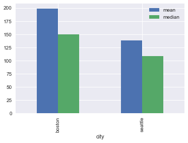

```python
df_calendar.groupby('city')['price'].agg([np.mean, np.median]).plot(kind='bar')
```

```python
#date to datetime format
df_calendar['date'] = pd.to_datetime(df_calendar['date'], format="%Y-%m-%d")
df_calendar.head()
```

|  | listing_id | date | available | price | city |
| --- | --- | --- | --- | --- | --- |
| 365 | 3075044 | 2017-08-22 | t | 65 | boston |
| 366 | 3075044 | 2017-08-21 | t | 65 | boston |
| 367 | 3075044 | 2017-08-20 | t | 65 | boston |
| 368 | 3075044 | 2017-08-19 | t | 75 | boston |
| 369 | 3075044 | 2017-08-18 | t | 75 | boston |

```python
#available to bool format
df_calendar.available.value_counts()
```

```
t    1577579
Name: available, dtype: int64
```

When the listing is available, we have a price, otherwise, the price is empty, therefore, **for every listing with a price, its availability state is true**.

```python
#drop acailable column
df_calendar.drop(axis=1, columns='available', inplace=True)
```

```python
df_calendar.info()
#This looks about right!
```

```
<class 'pandas.core.frame.DataFrame'>
Int64Index: 1577579 entries, 365 to 1393213
Data columns (total 4 columns):
 #   Column      Non-Null Count    Dtype
---  ------      --------------    -----
 0   listing_id  1577579 non-null  int64
 1   date        1577579 non-null  datetime64[ns]
 2   price       1577579 non-null  int64
 3   city        1577579 non-null  object
dtypes: datetime64[ns](1), int64(2), object(1)
memory usage: 60.2+ MB
```

##### Listing Data Wrangling & Cleaning

```python
#listing data with all other features
display(seattle_listings.market.value_counts())
display(boston_listings.market.value_counts())
```

```
Seattle    3818
Name: market, dtype: int64
```

```
Boston                   3568
San Francisco               1
Other (Domestic)            1
Other (International)       1
Name: market, dtype: int64
```

```python
# display(seattle_listings.smart_location.value_counts())
# display(boston_listings.smart_location.value_counts())
```

```python
boston_listings[boston_listings['market']!= 'Boston']
```

|  | id | listing_url | scrape_id | last_scraped | name | summary | space | description | experiences_offered | neighborhood_overview | notes | transit | access | interaction | house_rules | thumbnail_url | medium_url | picture_url | xl_picture_url | host_id | host_url | host_name | host_since | host_location | host_about | host_response_time | host_response_rate | host_acceptance_rate | host_is_superhost | … |
| --- | --- | --- | --- | --- | --- | --- | --- | --- | --- | --- | --- | --- | --- | --- | --- | --- | --- | --- | --- | --- | --- | --- | --- | --- | --- | --- | --- | --- | --- | --- |
| 12 | 2684840 | https://www.airbnb.com/rooms/2684840 | 20160906204935 | 2016-09-07 | Updated, spacious living in Rozzie | Clean, sunny 2 bedroom in amazing Roslindale V... | NaN | Clean, sunny 2 bedroom in amazing Roslindale V... | none | NaN | NaN | NaN | NaN | NaN | - One of the bedroom closets is not accessible... | https://a2.muscache.com/im/pictures/c15817b4-1... | https://a2.muscache.com/im/pictures/c15817b4-1... | https://a2.muscache.com/im/pictures/c15817b4-1... | https://a2.muscache.com/im/pictures/c15817b4-1... | 13743098 | https://www.airbnb.com/users/show/13743098 | Megan | 2014-03-31 | Boston, Massachusetts, United States | I am a working professional in biotech. I typi... | within a few hours | 100% | 100% | f | … |
| 282 | 14260905 | https://www.airbnb.com/rooms/14260905 | 20160906204935 | 2016-09-07 | Comfortable, convenient & affordable JP Apartment | Close to downtown Boston and in the trendy, ar... | The unit is on the first floor of a multi unit... | Close to downtown Boston and in the trendy, ar... | none | NaN | Nice quiet neighborhood | NaN | Guests have full access to this apartment. No... | Will be available for questions and informatio... | - Quiet hours from 10 p.m - 7 a.m. - No loud p... | https://a2.muscache.com/im/pictures/9cee336f-d... | https://a2.muscache.com/im/pictures/9cee336f-d... | https://a2.muscache.com/im/pictures/9cee336f-d... | https://a2.muscache.com/im/pictures/9cee336f-d... | 29890732 | https://www.airbnb.com/users/show/29890732 | Nancy | 2015-03-23 | Boston, Massachusetts, United States | NaN | within a day | 100% | 100% | f | … |
| 566 | 14246956 | https://www.airbnb.com/rooms/14246956 | 20160906204935 | 2016-09-07 | Tufts medical,Boston tourists,sleeps 6,ChinaTown | Steps to public transportation,Tufts Medical,C... | 4th floor apartment found in Boston's walking... | Steps to public transportation,Tufts Medical,C... | none | Great location to see tourist attractions, Tuf... | professional non smoking building | NaN | entire apartment | Keys will be in a lockbox, I am available by c... | NaN | https://a2.muscache.com/im/pictures/a257558e-b... | https://a2.muscache.com/im/pictures/a257558e-b... | https://a2.muscache.com/im/pictures/a257558e-b... | https://a2.muscache.com/im/pictures/a257558e-b... | 31340713 | https://www.airbnb.com/users/show/31340713 | Kama | 2015-04-16 | Boston, Massachusetts, United States | born and raised in Boston, I have been a real ... | within an hour | 100% | 100% | f | … |
| 649 | 13478348 | https://www.airbnb.com/rooms/13478348 | 20160906204935 | 2016-09-07 | Cozy 2BD North End apt | Charming 2BD in the heart of the north end is ... | Directly in the center of town, you are close ... | Charming 2BD in the heart of the north end is ... | none | Historic and beautiful North End is full of de... | NaN | T stops in walking distance are Haymarket, Aqu... | Guests will have access to entire apartment, w... | Someone will be there for key exchange and we ... | No smoking No pets No events or parties Check... | NaN | NaN | https://a2.muscache.com/im/pictures/1165e80f-a... | NaN | 76954514 | https://www.airbnb.com/users/show/76954514 | Rebecca | 2016-06-10 | Boston, Massachusetts, United States | Stay-at-home mom. Lover of travel, food, and b... | within a few hours | 100% | 68% | f | … |
| 806 | 13513696 | https://www.airbnb.com/rooms/13513696 | 20160906204935 | 2016-09-07 | 2BR South End Splendor w/ Private Deck | My place is close to Flour Bakery, Museum of F... | NaN | My place is close to Flour Bakery, Museum of F... | none | NaN | NaN | NaN | NaN | NaN | NaN | https://a2.muscache.com/im/pictures/74fa39a5-a... | https://a2.muscache.com/im/pictures/74fa39a5-a... | https://a2.muscache.com/im/pictures/74fa39a5-a... | https://a2.muscache.com/im/pictures/74fa39a5-a... | 48600417 | https://www.airbnb.com/users/show/48600417 | Max | 2015-11-09 | Cambridge, Massachusetts, United States | NaN | within an hour | 100% | 100% | f | … |
| 1523 | 12998272 | https://www.airbnb.com/rooms/12998272 | 20160906204935 | 2016-09-07 | 2 bedroom in the heart of Back Bay | My place is a short walk to Fenway Park, The S... | NaN | My place is a short walk to Fenway Park, The S... | none | NaN | NaN | NaN | NaN | NaN | NaN | https://a2.muscache.com/im/pictures/10771fbc-5... | https://a2.muscache.com/im/pictures/10771fbc-5... | https://a2.muscache.com/im/pictures/10771fbc-5... | https://a2.muscache.com/im/pictures/10771fbc-5... | 71647340 | https://www.airbnb.com/users/show/71647340 | Chris | 2016-05-12 | Boston, Massachusetts, United States | NaN | within a day | 78% | 67% | f | … |
| 1729 | 11837857 | https://www.airbnb.com/rooms/11837857 | 20160906204935 | 2016-09-07 | Freedom trail condo with amazing Boston views | My place is close to Freedom Trail, Bunker Hil... | This sunny, modern and spacious two-bedroom co... | My place is close to Freedom Trail, Bunker Hil... | none | Charlestown is Boston's oldest neighbourhood. ... | NaN | From our place, you can walk to TD Garden and ... | NaN | We won't be staying while you're here, but we'... | - We live in a rowhouse that contains three un... | https://a2.muscache.com/im/pictures/2a104ef0-9... | https://a2.muscache.com/im/pictures/2a104ef0-9... | https://a2.muscache.com/im/pictures/2a104ef0-9... | https://a2.muscache.com/im/pictures/2a104ef0-9... | 4100684 | https://www.airbnb.com/users/show/4100684 | Laurel | 2012-11-09 | Boston, Massachusetts, United States | NaN | within a few hours | 100% | 100% | f | … |
| 2272 | 13266833 | https://www.airbnb.com/rooms/13266833 | 20160906204935 | 2016-09-07 | Private Room in Back Bay Boston! SEPT 1 - JAN! | My place is close to Fenway Park, The Fens, Th... | NaN | My place is close to Fenway Park, The Fens, Th... | none | NaN | NaN | NaN | NaN | NaN | - Smoking only allowed out on the fire escape ... | https://a2.muscache.com/im/pictures/73b96bac-d... | https://a2.muscache.com/im/pictures/73b96bac-d... | https://a2.muscache.com/im/pictures/73b96bac-d... | https://a2.muscache.com/im/pictures/73b96bac-d... | 37703603 | https://www.airbnb.com/users/show/37703603 | Jenna | 2015-07-06 | Boston, Massachusetts, United States | NaN | within a day | 64% | 93% | f | … |
| 2411 | 14553171 | https://www.airbnb.com/rooms/14553171 | 20160906204935 | 2016-09-07 | Lovely studio in Boston | Note: Please let me know if you prefer other d... | This space, a one-bedroom studio with a kitche... | Note: Please let me know if you prefer other d... | none | This neighborhood is perfect for suiting those... | The studio is located on the 3rd floor of a bu... | The Northeastern University T stop (on the gre... | The studio is entirely yours for the duration ... | The studio is absolutely private, but I am alw... | Please, no smoking indoors. Do not climb onto ... | https://a2.muscache.com/im/pictures/219b58a7-8... | https://a2.muscache.com/im/pictures/219b58a7-8... | https://a2.muscache.com/im/pictures/219b58a7-8... | https://a2.muscache.com/im/pictures/219b58a7-8... | 27871255 | https://www.airbnb.com/users/show/27871255 | Tiff | 2015-02-17 | Boston, Massachusetts, United States | Hi, everyone :) \r\n\r\nI'm a software develop... | within an hour | 100% | 100% | f | … |
| 3043 | 13514017 | https://www.airbnb.com/rooms/13514017 | 20160906204935 | 2016-09-07 | Amazing Two Bedroom w/Boston Skyline Views! | My place is close to Faneuill Hall, Logan Airp... | NaN | My place is close to Faneuill Hall, Logan Airp... | none | NaN | NaN | NaN | NaN | NaN | NaN | https://a2.muscache.com/im/pictures/40a0bb31-2... | https://a2.muscache.com/im/pictures/40a0bb31-2... | https://a2.muscache.com/im/pictures/40a0bb31-2... | https://a2.muscache.com/im/pictures/40a0bb31-2... | 66378068 | https://www.airbnb.com/users/show/66378068 | Gabe | 2016-04-08 | US | NaN | within a few hours | 91% | 96% | f | … |
| 3232 | 13605196 | https://www.airbnb.com/rooms/13605196 | 20160906204935 | 2016-09-07 | Spacious Apartment Next to Beach, Restaurants/... | Walking Distance to Castle Island, Downtown, B... | NaN | Walking Distance to Castle Island, Downtown, B... | none | NaN | NaN | NaN | NaN | NaN | NaN | NaN | NaN | https://a2.muscache.com/im/pictures/84eb7537-a... | NaN | 26734256 | https://www.airbnb.com/users/show/26734256 | Mike | 2015-01-26 | Boston, Massachusetts, United States | NaN | within a day | 50% | 100% | f | … |
| 3276 | 13306033 | https://www.airbnb.com/rooms/13306033 | 20160906204935 | 2016-09-07 | Sunny in Southie - Trendy Downtown Digs | My place is good for couples, business travele... | This apartment completes your Boston experienc... | My place is good for couples, business travele... | none | The BEACH is a 10 minute walk due East (w/ pub... | NaN | Street PARKING is always available and always ... | There is heat and air-conditioning with centra... | We provide 24/7 responses to guests. | Feel free to wear house slippers to keep the p... | https://a2.muscache.com/im/pictures/d3da92ff-9... | https://a2.muscache.com/im/pictures/d3da92ff-9... | https://a2.muscache.com/im/pictures/d3da92ff-9... | https://a2.muscache.com/im/pictures/d3da92ff-9... | 20334603 | https://www.airbnb.com/users/show/20334603 | Stephen | 2014-08-20 | Boston, Massachusetts, United States | My name is Stephen. I currently live in Boston... | within an hour | 100% | 100% | f | … |
| 3357 | 13530359 | https://www.airbnb.com/rooms/13530359 | 20160906204935 | 2016-09-07 | August sublet in Allston (from 08/03) | My place is located in Allston, an area with a... | NaN | My place is located in Allston, an area with a... | none | Allston is a neighborhood with a lot of bars a... | NaN | The apartment is close to the T (Packcards cor... | Guests can access the room, kitchen, bathroom ... | I'm not going to be in Boston in August, but I... | NaN | https://a2.muscache.com/im/pictures/661113c7-6... | https://a2.muscache.com/im/pictures/661113c7-6... | https://a2.muscache.com/im/pictures/661113c7-6... | https://a2.muscache.com/im/pictures/661113c7-6... | 40220824 | https://www.airbnb.com/users/show/40220824 | Gerard | 2015-08-01 | Barcelona, Catalonia, Spain | NaN | within an hour | 100% | 100% | f | … |
| 3358 | 13355213 | https://www.airbnb.com/rooms/13355213 | 20160906204935 | 2016-09-07 | VERY convenient COUCH in a LUXURIOUS house nea... | My place is close to Boston University, Fenway... | The house is a brand new building. Everything ... | My place is close to Boston University, Fenway... | none | Allston/Brighton is a choice neighborhood of B... | We will generally have coffee or tea, fruit an... | Our house is at a 1 min walking distance from ... | As a guest you will have access to all the com... | We are always available as a concierge for adv... | - Respectable to other people | https://a2.muscache.com/im/pictures/e73d0f9d-7... | https://a2.muscache.com/im/pictures/e73d0f9d-7... | https://a2.muscache.com/im/pictures/e73d0f9d-7... | https://a2.muscache.com/im/pictures/e73d0f9d-7... | 25149641 | https://www.airbnb.com/users/show/25149641 | Rachid | 2014-12-23 | Boston, Massachusetts, United States | I am a scientist and a physician doing medical... | within an hour | 100% | 82% | f | … |
| 3375 | 13462519 | https://www.airbnb.com/rooms/13462519 | 20160906204935 | 2016-09-07 | PRIVATE & LUXURIOUS room in the center of BOSTON | This is a private, large, sunny and beautiful ... | NaN | This is a private, large, sunny and beautiful ... | none | NaN | NaN | NaN | NaN | NaN | - No shoes in house - Silence at night | https://a2.muscache.com/im/pictures/28160ea6-d... | https://a2.muscache.com/im/pictures/28160ea6-d... | https://a2.muscache.com/im/pictures/28160ea6-d... | https://a2.muscache.com/im/pictures/28160ea6-d... | 25149641 | https://www.airbnb.com/users/show/25149641 | Rachid | 2014-12-23 | Boston, Massachusetts, United States | I am a scientist and a physician doing medical... | within an hour | 100% | 82% | f | … |
| 3499 | 13126713 | https://www.airbnb.com/rooms/13126713 | 20160906204935 | 2016-09-07 | LUXURIOUS & PRIVATE room in the CENTER of Boston | This is a private, large, sunny and beautiful ... | The house is a brand new building. The space i... | This is a private, large, sunny and beautiful ... | none | Allston/Brighton is a choice neighborhood of B... | We will generally have coffee or tea, fruit an... | Our house is at a 1 min walking distance from ... | As a guest you will have access to all the com... | We are always available as a concierge for adv... | Share our house as a guest, don't worry about ... | https://a2.muscache.com/im/pictures/8c876b1e-4... | https://a2.muscache.com/im/pictures/8c876b1e-4... | https://a2.muscache.com/im/pictures/8c876b1e-4... | https://a2.muscache.com/im/pictures/8c876b1e-4... | 25149641 | https://www.airbnb.com/users/show/25149641 | Rachid | 2014-12-23 | Boston, Massachusetts, United States | I am a scientist and a physician doing medical... | within an hour | 100% | 82% | f | … |
| 3577 | 13750763 | https://www.airbnb.com/rooms/13750763 | 20160906204935 | 2016-09-07 | Comfortable Space in the Heart of Brookline | Our place is close to Coolidge Corner, Allston... | This space consists of 2 Rooms and a private b... | Our place is close to Coolidge Corner, Allston... | none | Brookline is known for being an excellent and ... | There is no parking available with this rental. | There are 2 green line trains within walking d... | NaN | We are typically available to offer assistance... | - Multiple night discounts apply for 3 or more... | https://a2.muscache.com/im/pictures/a998d5cd-8... | https://a2.muscache.com/im/pictures/a998d5cd-8... | https://a2.muscache.com/im/pictures/a998d5cd-8... | https://a2.muscache.com/im/pictures/a998d5cd-8... | 33906096 | https://www.airbnb.com/users/show/33906096 | Gillian | 2015-05-21 | Brookline, Massachusetts, United States | I am a professional woman, married to a wonder... | NaN | NaN | NaN | f | … |

```python
boston_listings[['house_rules', 'access', 'interaction']].head()
```

|  | house_rules | access | interaction |
| --- | --- | --- | --- |
| 0 | Clean up and treat the home the way you'd like... | You will have access to 2 bedrooms, a living r... | NaN |
| 1 | Pet friendly but please confirm with me if the... | Apt has one more bedroom (which I use) and lar... | If I am at home, I am likely working in my hom... |
| 2 | I encourage you to use my kitchen, cooking and... | I am living in the apartment during your stay,... | ABOUT ME: I'm a laid-back, friendly, unmarried... |
| 3 | - The bathroom and house are shared so please ... | The basement has a washer dryer and gym area. ... | We do live in the house therefore might be som... |
| 4 | Please no smoking in the house, porch or on th... | You will have access to the front and side por... | I love my city and really enjoy sharing it wit... |

```python
#combine two datasets
boston_listings['market']='Boston'
boston_listings.drop(labels=['house_rules', 'access', 'interaction'], axis=1, inplace=True)
df_listing = pd.concat([boston_listings, seattle_listings])
display(df_listing.head())
display(df_listing.tail())
```

|  | id | listing_url | scrape_id | last_scraped | name | summary | space | description | experiences_offered | neighborhood_overview | notes | transit | thumbnail_url | medium_url | picture_url | xl_picture_url | host_id | host_url | host_name | host_since | host_location | host_about | host_response_time | host_response_rate | host_acceptance_rate | host_is_superhost | host_thumbnail_url | host_picture_url | host_neighbourhood | … |
| --- | --- | --- | --- | --- | --- | --- | --- | --- | --- | --- | --- | --- | --- | --- | --- | --- | --- | --- | --- | --- | --- | --- | --- | --- | --- | --- | --- | --- | --- | --- |
| 0 | 12147973 | https://www.airbnb.com/rooms/12147973 | 20160906204935 | 2016-09-07 | Sunny Bungalow in the City | Cozy, sunny, family home. Master bedroom high... | The house has an open and cozy feel at the sam... | Cozy, sunny, family home. Master bedroom high... | none | Roslindale is quiet, convenient and friendly. ... | NaN | The bus stop is 2 blocks away, and frequent. B... | https://a2.muscache.com/im/pictures/c0842db1-e... | https://a2.muscache.com/im/pictures/c0842db1-e... | https://a2.muscache.com/im/pictures/c0842db1-e... | https://a2.muscache.com/im/pictures/c0842db1-e... | 31303940 | https://www.airbnb.com/users/show/31303940 | Virginia | 2015-04-15 | Boston, Massachusetts, United States | We are country and city connecting in our deck... | NaN | NaN | NaN | f | https://a2.muscache.com/im/pictures/5936fef0-b... | https://a2.muscache.com/im/pictures/5936fef0-b... | Roslindale | … |
| 1 | 3075044 | https://www.airbnb.com/rooms/3075044 | 20160906204935 | 2016-09-07 | Charming room in pet friendly apt | Charming and quiet room in a second floor 1910... | Small but cozy and quite room with a full size... | Charming and quiet room in a second floor 1910... | none | The room is in Roslindale, a diverse and prima... | If you don't have a US cell phone, you can tex... | Plenty of safe street parking. Bus stops a few... | https://a1.muscache.com/im/pictures/39327812/d... | https://a1.muscache.com/im/pictures/39327812/d... | https://a1.muscache.com/im/pictures/39327812/d... | https://a1.muscache.com/im/pictures/39327812/d... | 2572247 | https://www.airbnb.com/users/show/2572247 | Andrea | 2012-06-07 | Boston, Massachusetts, United States | I live in Boston and I like to travel and have... | within an hour | 100% | 100% | f | https://a2.muscache.com/im/users/2572247/profi... | https://a2.muscache.com/im/users/2572247/profi... | Roslindale | … |
| 2 | 6976 | https://www.airbnb.com/rooms/6976 | 20160906204935 | 2016-09-07 | Mexican Folk Art Haven in Boston | Come stay with a friendly, middle-aged guy in ... | Come stay with a friendly, middle-aged guy in ... | Come stay with a friendly, middle-aged guy in ... | none | The LOCATION: Roslindale is a safe and diverse... | I am in a scenic part of Boston with a couple ... | PUBLIC TRANSPORTATION: From the house, quick p... | https://a2.muscache.com/im/pictures/6ae8335d-9... | https://a2.muscache.com/im/pictures/6ae8335d-9... | https://a2.muscache.com/im/pictures/6ae8335d-9... | https://a2.muscache.com/im/pictures/6ae8335d-9... | 16701 | https://www.airbnb.com/users/show/16701 | Phil | 2009-05-11 | Boston, Massachusetts, United States | I am a middle-aged, single male with a wide ra... | within a few hours | 100% | 88% | t | https://a2.muscache.com/im/users/16701/profile... | https://a2.muscache.com/im/users/16701/profile... | Roslindale | … |
| 3 | 1436513 | https://www.airbnb.com/rooms/1436513 | 20160906204935 | 2016-09-07 | Spacious Sunny Bedroom Suite in Historic Home | Come experience the comforts of home away from... | Most places you find in Boston are small howev... | Come experience the comforts of home away from... | none | Roslindale is a lovely little neighborhood loc... | Please be mindful of the property as it is old... | There are buses that stop right in front of th... | https://a2.muscache.com/im/pictures/39764190-1... | https://a2.muscache.com/im/pictures/39764190-1... | https://a2.muscache.com/im/pictures/39764190-1... | https://a2.muscache.com/im/pictures/39764190-1... | 6031442 | https://www.airbnb.com/users/show/6031442 | Meghna | 2013-04-21 | Boston, Massachusetts, United States | My husband and I live on the property. He’s a... | within a few hours | 100% | 50% | f | https://a2.muscache.com/im/pictures/5d430cde-7... | https://a2.muscache.com/im/pictures/5d430cde-7... | NaN | … |
| 4 | 7651065 | https://www.airbnb.com/rooms/7651065 | 20160906204935 | 2016-09-07 | Come Home to Boston | My comfy, clean and relaxing home is one block... | Clean, attractive, private room, one block fro... | My comfy, clean and relaxing home is one block... | none | I love the proximity to downtown, the neighbor... | I have one roommate who lives on the lower lev... | From Logan Airport and South Station you have... | https://a1.muscache.com/im/pictures/97154760/8... | https://a1.muscache.com/im/pictures/97154760/8... | https://a1.muscache.com/im/pictures/97154760/8... | https://a1.muscache.com/im/pictures/97154760/8... | 15396970 | https://www.airbnb.com/users/show/15396970 | Linda | 2014-05-11 | Boston, Massachusetts, United States | I work full time for a public school district.... | within an hour | 100% | 100% | t | https://a0.muscache.com/im/users/15396970/prof... | https://a0.muscache.com/im/users/15396970/prof... | Roslindale | … |

|  | id | listing_url | scrape_id | last_scraped | name | summary | space | description | experiences_offered | neighborhood_overview | notes | transit | thumbnail_url | medium_url | picture_url | xl_picture_url | host_id | host_url | host_name | host_since | host_location | host_about | host_response_time | host_response_rate | host_acceptance_rate | host_is_superhost | host_thumbnail_url | host_picture_url | host_neighbourhood | … |
| --- | --- | --- | --- | --- | --- | --- | --- | --- | --- | --- | --- | --- | --- | --- | --- | --- | --- | --- | --- | --- | --- | --- | --- | --- | --- | --- | --- | --- | --- | --- |
| 3813 | 8101950 | https://www.airbnb.com/rooms/8101950 | 20160104002432 | 2016-01-04 | 3BR Mountain View House in Seattle | Our 3BR/2BA house boasts incredible views of t... | Our 3BR/2BA house bright, stylish, and wheelch... | Our 3BR/2BA house boasts incredible views of t... | none | We're located near lots of family fun. Woodlan... | NaN | NaN | https://a2.muscache.com/ac/pictures/103217071/... | https://a2.muscache.com/im/pictures/103217071/... | https://a2.muscache.com/ac/pictures/103217071/... | https://a2.muscache.com/ac/pictures/103217071/... | 31148752 | https://www.airbnb.com/users/show/31148752 | Bo | 2015-04-13 | US | NaN | within a few hours | 99% | 100% | f | https://a2.muscache.com/ac/users/31148752/prof... | https://a2.muscache.com/ac/users/31148752/prof... | Holly | … |
| 3814 | 8902327 | https://www.airbnb.com/rooms/8902327 | 20160104002432 | 2016-01-04 | Portage Bay View!-One Bedroom Apt | 800 square foot 1 bedroom basement apartment w... | This space has a great view of Portage Bay wit... | 800 square foot 1 bedroom basement apartment w... | none | The neighborhood is a quiet oasis that is clos... | This is a basement apartment in a newer reside... | Uber and Car2go are good options in Seattle. T... | https://a2.muscache.com/ac/pictures/626d4b1f-6... | https://a2.muscache.com/im/pictures/626d4b1f-6... | https://a2.muscache.com/ac/pictures/626d4b1f-6... | https://a2.muscache.com/ac/pictures/626d4b1f-6... | 46566046 | https://www.airbnb.com/users/show/46566046 | Glen | 2015-10-14 | Seattle, Washington, United States | I am a 58 year old male that is married to Mag... | within an hour | 100% | 100% | f | https://a2.muscache.com/ac/pictures/d7e59b0d-8... | https://a2.muscache.com/ac/pictures/d7e59b0d-8... | Portage Bay | … |
| 3815 | 10267360 | https://www.airbnb.com/rooms/10267360 | 20160104002432 | 2016-01-04 | Private apartment view of Lake WA | Very comfortable lower unit. Quiet, charming m... | NaN | Very comfortable lower unit. Quiet, charming m... | none | NaN | NaN | NaN | https://a2.muscache.com/ac/pictures/a5974f04-2... | https://a2.muscache.com/im/pictures/a5974f04-2... | https://a2.muscache.com/ac/pictures/a5974f04-2... | https://a2.muscache.com/ac/pictures/a5974f04-2... | 52791370 | https://www.airbnb.com/users/show/52791370 | Virginia | 2015-12-30 | US | NaN | NaN | NaN | NaN | f | https://a2.muscache.com/ac/pictures/efc75826-1... | https://a2.muscache.com/ac/pictures/efc75826-1... | NaN | … |
| 3816 | 9604740 | https://www.airbnb.com/rooms/9604740 | 20160104002432 | 2016-01-04 | Amazing View with Modern Comfort! | Cozy studio condo in the heart on Madison Park... | Fully furnished unit to accommodate most needs... | Cozy studio condo in the heart on Madison Park... | none | Madison Park offers a peaceful slow pace upsca... | NaN | Yes | https://a2.muscache.com/ac/pictures/202e4ad6-b... | https://a2.muscache.com/im/pictures/202e4ad6-b... | https://a2.muscache.com/ac/pictures/202e4ad6-b... | https://a2.muscache.com/ac/pictures/202e4ad6-b... | 25522052 | https://www.airbnb.com/users/show/25522052 | Karen | 2015-01-03 | Tacoma, Washington, United States | NaN | within an hour | 100% | NaN | f | https://a0.muscache.com/ac/users/25522052/prof... | https://a0.muscache.com/ac/users/25522052/prof... | NaN | … |
| 3817 | 10208623 | https://www.airbnb.com/rooms/10208623 | 20160104002432 | 2016-01-04 | Large Lakefront Apartment | All hardwood floors, fireplace, 65" TV with Xb... | NaN | All hardwood floors, fireplace, 65" TV with Xb... | none | NaN | Also our puppy will be boarded away. | NaN | https://a2.muscache.com/ac/pictures/596705b3-0... | https://a2.muscache.com/im/pictures/596705b3-0... | https://a2.muscache.com/ac/pictures/596705b3-0... | https://a2.muscache.com/ac/pictures/596705b3-0... | 14703116 | https://www.airbnb.com/users/show/14703116 | Gil | 2014-04-25 | Seattle, Washington, United States | NaN | within a day | 100% | NaN | f | https://a2.muscache.com/ac/pictures/8864f979-b... | https://a2.muscache.com/ac/pictures/8864f979-b... | Queen Anne | … |

```python
df_listing.shape
```

```
(7403, 92)
```

```python
# df_listing = pd.concat([boston_listings, seattle_listings])
```

```python
df_listing.info()
```

```
<class 'pandas.core.frame.DataFrame'>
Int64Index: 7403 entries, 0 to 3817
Data columns (total 92 columns):
 #   Column                            Non-Null Count  Dtype
---  ------                            --------------  -----
 0   id                                7403 non-null   int64
 1   listing_url                       7403 non-null   object
 2   scrape_id                         7403 non-null   int64
 3   last_scraped                      7403 non-null   object
 4   name                              7403 non-null   object
 5   summary                           7083 non-null   object
 6   space                             5777 non-null   object
 7   description                       7403 non-null   object
 8   experiences_offered               7403 non-null   object
 9   neighborhood_overview             4956 non-null   object
```

[output cut: 84 more lines]

```python
#missing cvalues%
df_listing.isnull().mean().sort_values(ascending=False)
```

```
license                            1.00000
square_feet                        0.97933
monthly_price                      0.67513
weekly_price                       0.60813
security_deposit                   0.56666
jurisdiction_names                 0.48426
has_availability                   0.48426
neighbourhood_group_cleansed       0.48426
notes                              0.48372
neighborhood_overview              0.33054
transit                            0.30042
host_about                         0.29285
cleaning_fee                       0.28867
space                              0.21964
review_scores_accuracy             0.20005
review_scores_checkin              0.19965
review_scores_value                0.19951
review_scores_location             0.19951
review_scores_cleanliness          0.19870
review_scores_communication        0.19843
review_scores_rating               0.19722
reviews_per_month                  0.18682
last_review                        0.18682
first_review                       0.18682
host_acceptance_rate               0.16804
host_response_rate                 0.13427
host_response_time                 0.13427
neighbourhood                      0.12954
thumbnail_url                      0.12414
medium_url                         0.12414
xl_picture_url                     0.12414
host_neighbourhood                 0.08632
summary                            0.04323
zipcode                            0.00608
bathrooms                          0.00405
host_location                      0.00257
bedrooms                           0.00216
beds                               0.00135
property_type                      0.00054
host_has_profile_pic               0.00027
```

[output cut: 38 more lines]

```
market                             0.00000
guests_included                    0.00000
smart_location                     0.00000
country_code                       0.00000
country                            0.00000
latitude                           0.00000
listing_url                        0.00000
is_location_exact                  0.00000
room_type                          0.00000
accommodates                       0.00000
bed_type                           0.00000
amenities                          0.00000
price                              0.00000
longitude                          0.00000
dtype: float64
```

There are quite a lot of columns for listings, and I am going to clean up the dataset by feature categories. I divided the listing features into the following categories:

1. **Home Information**
2. **Host Information**
3. **Location**
4. **Property Information**
5. **Price**
6. **Services**
7. **Availability**
8. **Reviews**

For each of the categories, I will check data columns for data types, missing values, and if there are any structural problems.

```python
df_listing_copy = df_listing
```

```python
#home information
index_home_info = ['id',
                    'listing_url',
                    'name',
                    'summary',
                    'space',
                    'description',
                    'notes',
                    'transit',
                    'thumbnail_url',
                    'medium_url',
                    'picture_url',
                    'xl_picture_url']
```

```python
#host infomation
index_host_info = ['host_id',
                    'host_url',
                    'host_name',
                    'host_since',
                    'host_location',
                    'host_about',
                    'host_response_time',
                    'host_response_rate',
                    'host_acceptance_rate',
                    'host_is_superhost',
                    'host_thumbnail_url',
                    'host_picture_url',
                    'host_neighbourhood',
                    'host_listings_count',
                    'host_total_listings_count',
                    'host_verifications',
                    'host_has_profile_pic',
                    'host_identity_verified']
```

```python
df_listing_copy.info()
```

```
<class 'pandas.core.frame.DataFrame'>
Int64Index: 7403 entries, 0 to 3817
Data columns (total 92 columns):
 #   Column                            Non-Null Count  Dtype
---  ------                            --------------  -----
 0   id                                7403 non-null   int64
 1   listing_url                       7403 non-null   object
 2   scrape_id                         7403 non-null   int64
 3   last_scraped                      7403 non-null   object
 4   name                              7403 non-null   object
 5   summary                           7083 non-null   object
 6   space                             5777 non-null   object
 7   description                       7403 non-null   object
 8   experiences_offered               7403 non-null   object
 9   neighborhood_overview             4956 non-null   object
```

[output cut: 84 more lines]

```python
df_listing_copy['host_response_rate'] = df_listing_copy['host_response_rate'].str.extract('(\d+)').astype(float)
df_listing_copy['host_response_rate'] = df_listing_copy['host_response_rate'] /100
```

```python
df_listing_copy['host_response_rate'].describe()
```

```
count   6409.00000
mean       0.94936
std        0.12187
min        0.00000
25%        0.97000
50%        1.00000
75%        1.00000
max        1.00000
Name: host_response_rate, dtype: float64
```

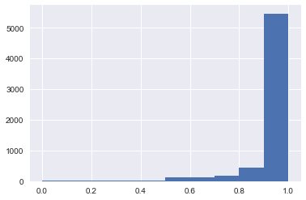

```python
df_listing_copy['host_response_rate'].hist()
```

```python
df_listing_copy.host_response_time.value_counts(dropna=False)
```

```
within an hour        3076
within a few hours    2186
within a day          1066
NaN                    994
a few days or more      81
Name: host_response_time, dtype: int64
```

```python
df_listing_copy['host_acceptance_rate'] = df_listing_copy['host_acceptance_rate'].str.extract('(\d+)').astype(float)
df_listing_copy['host_acceptance_rate'] = df_listing_copy['host_acceptance_rate'] /100
```

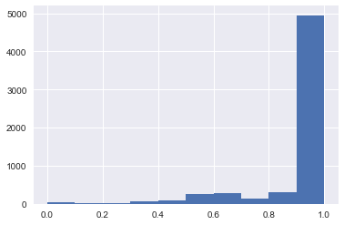

```python
df_listing_copy['host_acceptance_rate'].hist()
```

```python
def fun_string2boolean(col):
    '''
    Description: This function can be used to change a string columns with 't' and 'f'
    to boolean data type.

    Arguments:
    col: the column we want to change from object type to boolean
    it should contain only 't' as TRUE, 'f' as False, and NA values.

    Returns:
    new_col: a boolean type column
    '''
    new_col = col.map({'t': True, 'f': False})
    return new_col
```

```python
df_listing_copy['host_is_superhost'] = fun_string2boolean(df_listing_copy['host_is_superhost'])
df_listing_copy['host_has_profile_pic'] = fun_string2boolean(df_listing_copy['host_has_profile_pic'])
df_listing_copy['host_identity_verified'] = fun_string2boolean(df_listing_copy['host_identity_verified'])
```

```python
df_listing_copy['host_is_superhost'].value_counts(dropna=False)
```

```
False    6216
True     1185
NaN         2
Name: host_is_superhost, dtype: int64
```

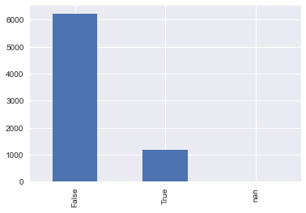

```python
df_listing_copy['host_is_superhost'].value_counts(dropna=False).plot(kind='bar')
```

```python
df_listing_copy['host_has_profile_pic'].value_counts(dropna=False)
```

```
True     7386
False      15
NaN         2
Name: host_has_profile_pic, dtype: int64
```

```python
df_listing_copy['host_identity_verified'].value_counts(dropna=False)
```

```
True     5600
False    1801
NaN         2
Name: host_identity_verified, dtype: int64
```

```python
#location
index_loc = ['neighborhood_overview',
            'street',
            'neighbourhood_group_cleansed',
            'neighbourhood_cleansed',
            'state',
            'zipcode',
            'market',
            'country_code',
            'country',
            'latitude',
            'longitude',
            'is_location_exact']
```

```python
# df_listing_copy[index_loc].head()
```

```python
df_listing_copy[['market', 'neighbourhood']].value_counts()
```

```
market   neighbourhood
Boston   Allston-Brighton             364
Seattle  Capitol Hill                 351
Boston   Jamaica Plain                314
         South End                    298
         Back Bay                     291
         Fenway/Kenmore               249
         South Boston                 216
Seattle  Ballard                      213
         Belltown                     204
Boston   Dorchester                   195
Seattle  Minor                        192
         Queen Anne                   187
Boston   Beacon Hill                  174
Seattle  Fremont                      148
         Wallingford                  143
Boston   North End                    125
         East Boston                  117
         Roxbury                      116
Seattle  University District          107
         First Hill                   105
Boston   Mission Hill                 103
Seattle  Stevens                       98
         North Beacon Hill             95
         Lower Queen Anne              83
         Central Business District     81
         Greenwood                     79
Boston   Charlestown                   79
         Chinatown                     78
         West End                      68
Seattle  Columbia City                 61
         Ravenna                       59
         Phinney Ridge                 56
         Magnolia                      55
         Green Lake                    52
         Atlantic                      50
Boston   Roslindale                    50
Seattle  North Admiral                 48
         Mount Baker                   46
         Leschi                        44
```

[output cut: 58 more lines]

```
         Broadway                       5
         Brighton                       5
Boston   Chestnut Hill                  4
Seattle  Arbor Heights                  3
Boston   Government Center              3
Seattle  Pinehurst                      3
         Industrial District            3
         South Beacon Hill              2
         South Park                     2
         Pike Market                    2
Boston   Harvard Square                 2
Seattle  Fairmount Park                 1
         North College Park             1
         Roxhill                        1
dtype: int64
```

```python
#keep 'neighbourhood_cleansed'
df_listing_copy[['market','neighbourhood_cleansed']].value_counts()
```

```
market   neighbourhood_cleansed
Seattle  Broadway                     397
Boston   Jamaica Plain                343
         South End                    326
         Back Bay                     302
         Fenway                       290
         Dorchester                   269
         Allston                      260
Seattle  Belltown                     234
Boston   Beacon Hill                  194
         Brighton                     185
         South Boston                 174
         Downtown                     172
Seattle  Wallingford                  167
         Fremont                      158
Boston   East Boston                  150
         Roxbury                      144
         North End                    143
Seattle  Minor                        135
Boston   Mission Hill                 124
Seattle  University District          122
         Stevens                      119
Boston   Charlestown                  111
Seattle  First Hill                   108
         Central Business District    103
         Lower Queen Anne              94
         Greenwood                     89
Boston   South Boston Waterfront       83
Seattle  East Queen Anne               82
         North Beacon Hill             78
         Phinney Ridge                 73
Boston   Chinatown                     71
Seattle  Adams                         70
         Ravenna                       67
         Mann                          67
         West Queen Anne               65
         West Woodland                 64
         Columbia City                 58
Boston   Roslindale                    56
Seattle  North Queen Anne              54
```

[output cut: 59 more lines]

```
         Meadowbrook                    9
Boston   Longwood Medical Area          9
Seattle  Riverview                      8
         Georgetown                     8
         Cedar Park                     8
         View Ridge                     7
         Industrial District            6
         Holly Park                     6
         Arbor Heights                  5
Boston   Leather District               5
Seattle  Pinehurst                      4
         South Beacon Hill              4
         South Park                     3
         Roxhill                        2
dtype: int64
```

```python
#keep 'neighbourhood_group_cleansed' for Seattle market
df_listing_copy[['market','neighbourhood_group_cleansed']].value_counts()
```

```
market   neighbourhood_group_cleansed
Seattle  Other neighborhoods             794
         Capitol Hill                    567
         Downtown                        530
         Central Area                    369
         Queen Anne                      295
         Ballard                         230
         West Seattle                    203
         Rainier Valley                  159
         University District             122
         Beacon Hill                     118
         Cascade                          89
         Northgate                        80
         Delridge                         79
         Lake City                        67
         Magnolia                         61
         Seward Park                      44
         Interbay                         11
dtype: int64
```

```python
#there is no need to keep 'city', will use 'market' instead
df_listing_copy['city'].value_counts()
```

```
Seattle                      3810
Boston                       3381
Roxbury Crossing               24
Somerville                     19
Jamaica Plain                  18
Brookline                      18
Cambridge                      16
Brighton                       15
Dorchester                     15
Charlestown                    15
Allston                        12
Roslindale                      6
West Roxbury                    5
ROXBURY CROSSING                4
East Boston                     3
Mattapan                        3
Hyde Park                       2
Boston, Massachusetts, US       2
South Boston                    2
West Seattle                    2
Seattle                         2
Jamaica Plain                   2
Jamaica Plain, Boston           2
ALLSTON                         2
Ballard, Seattle                1
dorchester, boston              1
西雅图                             1
Phinney Ridge Seattle           1
Milton                          1
Boston (Charlestown)            1
Newton                          1
Boston                          1
Brighton                        1
Watertown                       1
east Boston                     1
South End, Boston               1
波士顿                             1
boston                          1
Mission Hill, Boston            1
Jamaica plain                   1
Boston (Jamaica Plain)          1
Jamaica Plain, MA               1
Jamaica Plain (Boston)          1
Roslindale, Boston              1
seattle                         1
Name: city, dtype: int64
```

```python
df_listing_copy['state'].value_counts(dropna=False)
```

```
WA    3817
MA    3585
wa       1
Name: state, dtype: int64
```

```python
df_listing_copy['state'] = df_listing_copy['state'].replace(['wa'], 'WA')
```

```python
df_listing_copy['zipcode'].value_counts()
```

```
98122          420
98103          394
02116          388
98102          339
02130          331
02118          247
02215          236
02134          232
02114          231
98105          225
98109          202
98101          201
98144          200
98121          196
98107          180
```

[output cut: 57 more lines]

```python
df_listing_copy['zipcode'] = df_listing_copy['zipcode'].replace(['99\n98122', '02108 02111', '02134-1704'], ['98122', '02108', '02134'])
```

```python
#there is no need to keep 'smart_location'
df_listing_copy['smart_location'].value_counts()
```

```
Seattle, WA                      3810
Boston, MA                       3381
Roxbury Crossing, MA               24
Somerville, MA                     19
Brookline, MA                      18
Jamaica Plain, MA                  18
Cambridge, MA                      16
Dorchester, MA                     15
Charlestown, MA                    15
Brighton, MA                       15
Allston, MA                        12
Roslindale, MA                      6
West Roxbury, MA                    5
ROXBURY CROSSING, MA                4
Mattapan, MA                        3
East Boston, MA                     3
MA                                  2
South Boston, MA                    2
Jamaica Plain, Boston, MA           2
ALLSTON, MA                         2
Jamaica Plain , MA                  2
West Seattle, WA                    2
Boston, Massachusetts, US, MA       2
Seattle , WA                        2
Hyde Park, MA                       2
Roslindale, Boston, MA              1
Ballard, Seattle, WA                1
西雅图, WA                             1
dorchester, boston , MA             1
Jamaica Plain (Boston), MA          1
Phinney Ridge Seattle, WA           1
Milton, MA                          1
Boston (Jamaica Plain), MA          1
Newton, MA                          1
Jamaica plain , MA                  1
Boston , MA                         1
Brighton , MA                       1
Watertown, MA                       1
Boston (Charlestown), MA            1
east Boston , MA                    1
Jamaica Plain, MA, MA               1
South End, Boston, MA               1
波士顿, MA                             1
boston, MA                          1
Mission Hill, Boston, MA            1
seattle, wa                         1
Name: smart_location, dtype: int64
```

```python
df_listing_copy['country_code'].value_counts()
```

```
US    7403
Name: country_code, dtype: int64
```

```python
df_listing_copy['country'].value_counts()
```

```
United States    7403
Name: country, dtype: int64
```

```python
df_listing_copy['is_location_exact'].value_counts(dropna=False)
```

```
t    6492
f     911
Name: is_location_exact, dtype: int64
```

```python
df_listing_copy['is_location_exact'] = fun_string2boolean(df_listing_copy['is_location_exact'])
```

```python
#price
index_price = ['price',
                'weekly_price',
                'monthly_price',
                'security_deposit',
                'cleaning_fee',
                'extra_people']
```

```python
df_listing_copy[index_price].dtypes
```

```
price               object
weekly_price        object
monthly_price       object
security_deposit    object
cleaning_fee        object
extra_people        object
dtype: object
```

```python
for col in index_price:
    df_listing_copy[col] =  df_listing_copy[col].str.replace(',','').str.extract('(\d+)').astype(float)
```

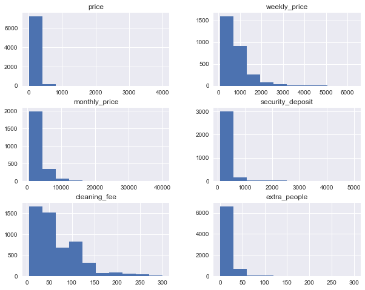

```python
df_listing_copy[index_price].hist(figsize=(10, 8));
```

```python
df_listing_copy[index_price].isnull().mean()
```

```
price              0.00000
weekly_price       0.60813
monthly_price      0.67513
security_deposit   0.56666
cleaning_fee       0.28867
extra_people       0.00000
dtype: float64
```

```python
#property information
index_proper_info = ['property_type',
                    'room_type',
                    'accommodates',
                    'bathrooms',
                    'bedrooms',
                    'beds',
                    'bed_type',
                    'amenities']
```

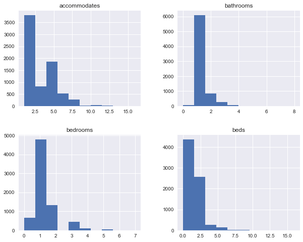

```python
df_listing_copy[index_proper_info].hist(figsize=(10, 8));
```

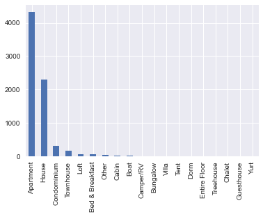

```python
df_listing_copy['property_type'].value_counts().plot(kind='bar');
```

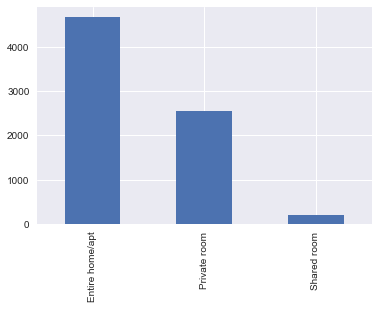

```python
df_listing_copy['room_type'].value_counts().plot(kind='bar');
```

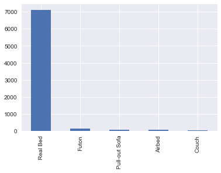

```python
df_listing_copy['bed_type'].value_counts().plot(kind='bar');
```

```python
#no need to keep requires_license as they're all false
df_listing_copy.requires_license.value_counts(dropna=False)
```

```
f    7403
Name: requires_license, dtype: int64
```

```python
#no need to keep jurisdiction_names ae they should be the same
df_listing_copy.jurisdiction_names.value_counts(dropna=False)
```

```
WASHINGTON    3818
NaN           3585
Name: jurisdiction_names, dtype: int64
```

```python
#services
index_svs = ['guests_included',
            'minimum_nights',
            'maximum_nights',
            'instant_bookable',
            'cancellation_policy',
            'require_guest_profile_picture',
            'require_guest_phone_verification',
            'calculated_host_listings_count']
```

```python
df_listing_copy[index_svs].head()
```

|  | guests_included | minimum_nights | maximum_nights | instant_bookable | cancellation_policy | require_guest_profile_picture | require_guest_phone_verification | calculated_host_listings_count |
| --- | --- | --- | --- | --- | --- | --- | --- | --- |
| 0 | 1 | 2 | 1125 | f | moderate | f | f | 1 |
| 1 | 0 | 2 | 15 | t | moderate | f | f | 1 |
| 2 | 1 | 3 | 45 | f | moderate | t | f | 1 |
| 3 | 2 | 1 | 1125 | f | moderate | f | f | 1 |
| 4 | 1 | 2 | 31 | f | flexible | f | f | 1 |

```python
df_listing_copy[index_svs].dtypes
```

```
guests_included                      int64
minimum_nights                       int64
maximum_nights                       int64
instant_bookable                    object
cancellation_policy                 object
require_guest_profile_picture       object
require_guest_phone_verification    object
calculated_host_listings_count       int64
dtype: object
```

```python
#there is no need to keep 'experiences_offered' because they're all none
df_listing_copy['experiences_offered'].value_counts(dropna=False)
```

```
none    7403
Name: experiences_offered, dtype: int64
```

```python
df_listing_copy['instant_bookable'].value_counts(dropna=False)
```

```
f    6218
t    1185
Name: instant_bookable, dtype: int64
```

```python
df_listing_copy['require_guest_profile_picture'].value_counts(dropna=False)
```

```
f    7015
t     388
Name: require_guest_profile_picture, dtype: int64
```

```python
df_listing_copy['require_guest_phone_verification'].value_counts(dropna=False)
```

```
f    6791
t     612
Name: require_guest_phone_verification, dtype: int64
```

```python
df_listing_copy['require_guest_profile_picture'] = fun_string2boolean(df_listing_copy['require_guest_profile_picture'])
df_listing_copy['require_guest_phone_verification'] = fun_string2boolean(df_listing_copy['require_guest_phone_verification'])
df_listing_copy['instant_bookable'] = fun_string2boolean(df_listing_copy['instant_bookable'])
```

```python
df_listing_copy['cancellation_policy'].value_counts(dropna=False)
```

```
strict             2999
moderate           2170
flexible           2149
super_strict_30      85
Name: cancellation_policy, dtype: int64
```

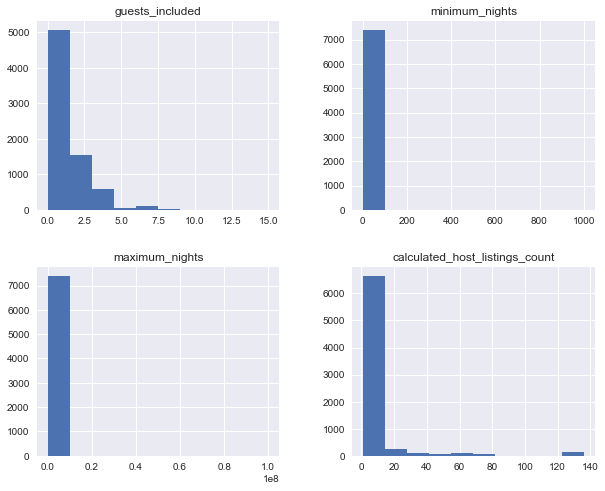

```python
df_listing_copy[index_svs].hist(figsize=(10,8));
```

```python
df_listing_copy['maximum_nights'].describe()
```

```
count       7403.00000
mean       14313.36944
std      1162232.12958
min            1.00000
25%           95.50000
50%         1125.00000
75%         1125.00000
max     99999999.00000
Name: maximum_nights, dtype: float64
```

```python
#reviews
index_rve = ['number_of_reviews',
            'first_review',
            'last_review',
            'review_scores_rating',
            'review_scores_accuracy',
            'review_scores_cleanliness',
            'review_scores_checkin',
            'review_scores_communication',
            'review_scores_location',
            'review_scores_value',
            'reviews_per_month']
```

```python
df_listing_copy[index_rve].dtypes
```

```
number_of_reviews                int64
first_review                    object
last_review                     object
review_scores_rating           float64
review_scores_accuracy         float64
review_scores_cleanliness      float64
review_scores_checkin          float64
review_scores_communication    float64
review_scores_location         float64
review_scores_value            float64
reviews_per_month              float64
dtype: object
```

```python
df_listing_copy['first_review'] = pd.to_datetime(df_listing_copy['first_review'], format="%Y-%m-%d")
df_listing_copy['last_review'] = pd.to_datetime(df_listing_copy['last_review'], format="%Y-%m-%d")
```

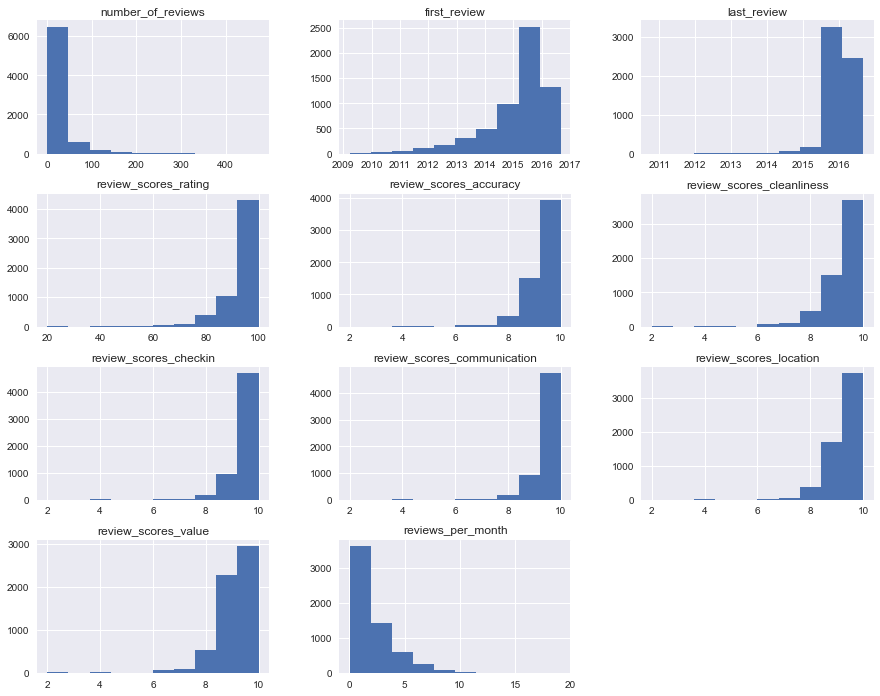

```python
df_listing_copy[index_rve].hist(figsize=(15,12));
```

```python
#availability
index_avb = ['availability_30',
            'availability_60',
            'availability_90',
            'availability_365']
```

```python
df_listing_copy[index_avb].dtypes
```

```
availability_30     int64
availability_60     int64
availability_90     int64
availability_365    int64
dtype: object
```

```python
df_listing_copy['has_availability'].value_counts(dropna=False)
```

```
t      3818
NaN    3585
Name: has_availability, dtype: int64
```

```python
#no need to keep has_availability because it is truen when there are prices provided
df_listing_copy[['market', 'has_availability']].value_counts(dropna=False)
```

```
market   has_availability
Seattle  t                   3818
Boston   NaN                 3585
dtype: int64
```

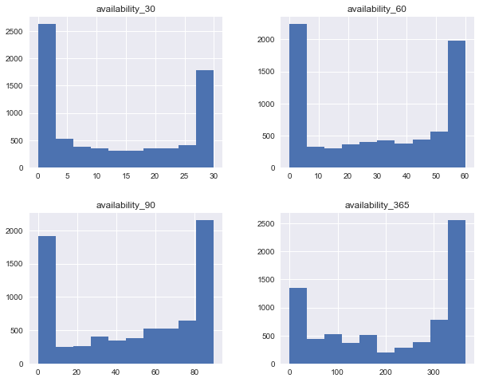

```python
df_listing_copy[index_avb].hist(figsize=(10,8));
```

```python
df_listing_copy[index_avb].describe()
```

|  | availability_30 | availability_60 | availability_90 | availability_365 |
| --- | --- | --- | --- | --- |
| count | 7403.00000 | 7403.00000 | 7403.00000 | 7403.00000 |
| mean | 12.84614 | 29.55977 | 48.62758 | 213.08915 |
| std | 12.06996 | 23.83940 | 35.01331 | 138.34284 |
| min | 0.00000 | 0.00000 | 0.00000 | 0.00000 |
| 25% | 0.00000 | 1.00000 | 7.00000 | 77.00000 |
| 50% | 10.00000 | 31.00000 | 56.00000 | 259.00000 |
| 75% | 26.00000 | 55.00000 | 84.00000 | 347.00000 |
| max | 30.00000 | 60.00000 | 90.00000 | 365.00000 |

```python
%who
```

```
LinearRegression	 boston_calendar	 boston_listings	 boston_reviews	 col	 df_calendar	 df_listing	 df_listing_copy	 display
fun_string2boolean	 index_avb	 index_home_info	 index_host_info	 index_loc	 index_price	 index_proper_info	 index_rve	 index_svs
mean_squared_error	 np	 pd	 plt	 r2_score	 seattle_calendar	 seattle_listings	 seattle_reviews	 sns
train_test_split
```

```python
[index_home_info+index_host_info+index_loc]
```

```
[['id',
  'listing_url',
  'name',
  'summary',
  'space',
  'description',
  'notes',
  'transit',
  'thumbnail_url',
  'medium_url',
  'picture_url',
  'xl_picture_url',
  'host_id',
  'host_url',
  'host_name',
  'host_since',
  'host_location',
  'host_about',
  'host_response_time',
  'host_response_rate',
  'host_acceptance_rate',
  'host_is_superhost',
  'host_thumbnail_url',
  'host_picture_url',
  'host_neighbourhood',
  'host_listings_count',
  'host_total_listings_count',
  'host_verifications',
  'host_has_profile_pic',
  'host_identity_verified',
  'neighborhood_overview',
  'street',
  'neighbourhood_group_cleansed',
  'neighbourhood_cleansed',
  'state',
  'zipcode',
  'market',
  'country_code',
  'country',
  'latitude',
  'longitude',
  'is_location_exact']]
```

```python
df_listing_clean = df_listing_copy[index_home_info+index_host_info+index_loc+index_price+index_proper_info+index_svs+index_avb+index_rve]
```

```python
#now I have a clean listing dataset!
df_listing_clean.head()
```

|  | id | listing_url | name | summary | space | description | notes | transit | thumbnail_url | medium_url | picture_url | xl_picture_url | host_id | host_url | host_name | host_since | host_location | host_about | host_response_time | host_response_rate | host_acceptance_rate | host_is_superhost | host_thumbnail_url | host_picture_url | host_neighbourhood | host_listings_count | host_total_listings_count | host_verifications | host_has_profile_pic | … |
| --- | --- | --- | --- | --- | --- | --- | --- | --- | --- | --- | --- | --- | --- | --- | --- | --- | --- | --- | --- | --- | --- | --- | --- | --- | --- | --- | --- | --- | --- | --- |
| 0 | 12147973 | https://www.airbnb.com/rooms/12147973 | Sunny Bungalow in the City | Cozy, sunny, family home. Master bedroom high... | The house has an open and cozy feel at the sam... | Cozy, sunny, family home. Master bedroom high... | NaN | The bus stop is 2 blocks away, and frequent. B... | https://a2.muscache.com/im/pictures/c0842db1-e... | https://a2.muscache.com/im/pictures/c0842db1-e... | https://a2.muscache.com/im/pictures/c0842db1-e... | https://a2.muscache.com/im/pictures/c0842db1-e... | 31303940 | https://www.airbnb.com/users/show/31303940 | Virginia | 2015-04-15 | Boston, Massachusetts, United States | We are country and city connecting in our deck... | NaN | NaN | NaN | False | https://a2.muscache.com/im/pictures/5936fef0-b... | https://a2.muscache.com/im/pictures/5936fef0-b... | Roslindale | 1.00000 | 1.00000 | ['email', 'phone', 'facebook', 'reviews'] | True | … |
| 1 | 3075044 | https://www.airbnb.com/rooms/3075044 | Charming room in pet friendly apt | Charming and quiet room in a second floor 1910... | Small but cozy and quite room with a full size... | Charming and quiet room in a second floor 1910... | If you don't have a US cell phone, you can tex... | Plenty of safe street parking. Bus stops a few... | https://a1.muscache.com/im/pictures/39327812/d... | https://a1.muscache.com/im/pictures/39327812/d... | https://a1.muscache.com/im/pictures/39327812/d... | https://a1.muscache.com/im/pictures/39327812/d... | 2572247 | https://www.airbnb.com/users/show/2572247 | Andrea | 2012-06-07 | Boston, Massachusetts, United States | I live in Boston and I like to travel and have... | within an hour | 1.00000 | 1.00000 | False | https://a2.muscache.com/im/users/2572247/profi... | https://a2.muscache.com/im/users/2572247/profi... | Roslindale | 1.00000 | 1.00000 | ['email', 'phone', 'facebook', 'linkedin', 'am... | True | … |
| 2 | 6976 | https://www.airbnb.com/rooms/6976 | Mexican Folk Art Haven in Boston | Come stay with a friendly, middle-aged guy in ... | Come stay with a friendly, middle-aged guy in ... | Come stay with a friendly, middle-aged guy in ... | I am in a scenic part of Boston with a couple ... | PUBLIC TRANSPORTATION: From the house, quick p... | https://a2.muscache.com/im/pictures/6ae8335d-9... | https://a2.muscache.com/im/pictures/6ae8335d-9... | https://a2.muscache.com/im/pictures/6ae8335d-9... | https://a2.muscache.com/im/pictures/6ae8335d-9... | 16701 | https://www.airbnb.com/users/show/16701 | Phil | 2009-05-11 | Boston, Massachusetts, United States | I am a middle-aged, single male with a wide ra... | within a few hours | 1.00000 | 0.88000 | True | https://a2.muscache.com/im/users/16701/profile... | https://a2.muscache.com/im/users/16701/profile... | Roslindale | 1.00000 | 1.00000 | ['email', 'phone', 'reviews', 'jumio'] | True | … |
| 3 | 1436513 | https://www.airbnb.com/rooms/1436513 | Spacious Sunny Bedroom Suite in Historic Home | Come experience the comforts of home away from... | Most places you find in Boston are small howev... | Come experience the comforts of home away from... | Please be mindful of the property as it is old... | There are buses that stop right in front of th... | https://a2.muscache.com/im/pictures/39764190-1... | https://a2.muscache.com/im/pictures/39764190-1... | https://a2.muscache.com/im/pictures/39764190-1... | https://a2.muscache.com/im/pictures/39764190-1... | 6031442 | https://www.airbnb.com/users/show/6031442 | Meghna | 2013-04-21 | Boston, Massachusetts, United States | My husband and I live on the property. He’s a... | within a few hours | 1.00000 | 0.50000 | False | https://a2.muscache.com/im/pictures/5d430cde-7... | https://a2.muscache.com/im/pictures/5d430cde-7... | NaN | 1.00000 | 1.00000 | ['email', 'phone', 'reviews'] | True | … |
| 4 | 7651065 | https://www.airbnb.com/rooms/7651065 | Come Home to Boston | My comfy, clean and relaxing home is one block... | Clean, attractive, private room, one block fro... | My comfy, clean and relaxing home is one block... | I have one roommate who lives on the lower lev... | From Logan Airport and South Station you have... | https://a1.muscache.com/im/pictures/97154760/8... | https://a1.muscache.com/im/pictures/97154760/8... | https://a1.muscache.com/im/pictures/97154760/8... | https://a1.muscache.com/im/pictures/97154760/8... | 15396970 | https://www.airbnb.com/users/show/15396970 | Linda | 2014-05-11 | Boston, Massachusetts, United States | I work full time for a public school district.... | within an hour | 1.00000 | 1.00000 | True | https://a0.muscache.com/im/users/15396970/prof... | https://a0.muscache.com/im/users/15396970/prof... | Roslindale | 1.00000 | 1.00000 | ['email', 'phone', 'reviews', 'kba'] | True | … |

```python
%who
```

```
LinearRegression	 boston_calendar	 boston_listings	 boston_reviews	 col	 df_calendar	 df_listing	 df_listing_clean	 df_listing_copy
display	 fun_string2boolean	 index_avb	 index_home_info	 index_host_info	 index_loc	 index_price	 index_proper_info	 index_rve
index_svs	 mean_squared_error	 np	 pd	 plt	 r2_score	 seattle_calendar	 seattle_listings	 seattle_reviews
sns	 train_test_split
```

`Results`: Now I have two main datasets I can use to answer the business questions more efficiently!

- **df_calendar**
- **df_listing_clean**

#### Part III: Modelling & Evaluation

In `Part III` of the Airbnb Project, I will use datasets from last part to answer the three questions one by one.

##### Question 1: How much Airbnb homes are earning in different neighbourhoods and seasons in Boston and Seattle?

```python
#calendar dataframe has datetime/seasons data
df_calendar.head()
```

|  | listing_id | date | price | city |
| --- | --- | --- | --- | --- |
| 365 | 3075044 | 2017-08-22 | 65 | boston |
| 366 | 3075044 | 2017-08-21 | 65 | boston |
| 367 | 3075044 | 2017-08-20 | 65 | boston |
| 368 | 3075044 | 2017-08-19 | 75 | boston |
| 369 | 3075044 | 2017-08-18 | 75 | boston |

```python
#listing dataframe has neighbourhoods data
pd.set_option('mode.chained_assignment', None)
df_listing_clean['market'] = df_listing_clean['market'].str.lower()
df_listing_clean.head(2)
```

|  | id | listing_url | name | summary | space | description | notes | transit | thumbnail_url | medium_url | picture_url | xl_picture_url | host_id | host_url | host_name | host_since | host_location | host_about | host_response_time | host_response_rate | host_acceptance_rate | host_is_superhost | host_thumbnail_url | host_picture_url | host_neighbourhood | host_listings_count | host_total_listings_count | host_verifications | host_has_profile_pic | … |
| --- | --- | --- | --- | --- | --- | --- | --- | --- | --- | --- | --- | --- | --- | --- | --- | --- | --- | --- | --- | --- | --- | --- | --- | --- | --- | --- | --- | --- | --- | --- |
| 0 | 12147973 | https://www.airbnb.com/rooms/12147973 | Sunny Bungalow in the City | Cozy, sunny, family home. Master bedroom high... | The house has an open and cozy feel at the sam... | Cozy, sunny, family home. Master bedroom high... | NaN | The bus stop is 2 blocks away, and frequent. B... | https://a2.muscache.com/im/pictures/c0842db1-e... | https://a2.muscache.com/im/pictures/c0842db1-e... | https://a2.muscache.com/im/pictures/c0842db1-e... | https://a2.muscache.com/im/pictures/c0842db1-e... | 31303940 | https://www.airbnb.com/users/show/31303940 | Virginia | 2015-04-15 | Boston, Massachusetts, United States | We are country and city connecting in our deck... | NaN | NaN | NaN | False | https://a2.muscache.com/im/pictures/5936fef0-b... | https://a2.muscache.com/im/pictures/5936fef0-b... | Roslindale | 1.00000 | 1.00000 | ['email', 'phone', 'facebook', 'reviews'] | True | … |
| 1 | 3075044 | https://www.airbnb.com/rooms/3075044 | Charming room in pet friendly apt | Charming and quiet room in a second floor 1910... | Small but cozy and quite room with a full size... | Charming and quiet room in a second floor 1910... | If you don't have a US cell phone, you can tex... | Plenty of safe street parking. Bus stops a few... | https://a1.muscache.com/im/pictures/39327812/d... | https://a1.muscache.com/im/pictures/39327812/d... | https://a1.muscache.com/im/pictures/39327812/d... | https://a1.muscache.com/im/pictures/39327812/d... | 2572247 | https://www.airbnb.com/users/show/2572247 | Andrea | 2012-06-07 | Boston, Massachusetts, United States | I live in Boston and I like to travel and have... | within an hour | 1.00000 | 1.00000 | False | https://a2.muscache.com/im/users/2572247/profi... | https://a2.muscache.com/im/users/2572247/profi... | Roslindale | 1.00000 | 1.00000 | ['email', 'phone', 'facebook', 'linkedin', 'am... | True | … |

```python
#merge data together
df_q1 = df_calendar.merge(df_listing_clean[['id', 'market', 'neighbourhood_cleansed', 'neighbourhood_group_cleansed']], how='left', left_on=['listing_id', 'city'], right_on=['id', 'market'])
```

```python
df_q1.head()
```

|  | listing_id | date | price | city | id | market | neighbourhood_cleansed | neighbourhood_group_cleansed |
| --- | --- | --- | --- | --- | --- | --- | --- | --- |
| 0 | 3075044 | 2017-08-22 | 65 | boston | 3075044 | boston | Roslindale | NaN |
| 1 | 3075044 | 2017-08-21 | 65 | boston | 3075044 | boston | Roslindale | NaN |
| 2 | 3075044 | 2017-08-20 | 65 | boston | 3075044 | boston | Roslindale | NaN |
| 3 | 3075044 | 2017-08-19 | 75 | boston | 3075044 | boston | Roslindale | NaN |
| 4 | 3075044 | 2017-08-18 | 75 | boston | 3075044 | boston | Roslindale | NaN |

```python
df_q1.shape
```

```
(1577579, 8)
```

```python
#price by year_month
df_q1['year_month'] = df_q1['date'].dt.strftime('%Y-%m')
df_q1.head()
```

|  | listing_id | date | price | city | id | market | neighbourhood_cleansed | neighbourhood_group_cleansed | year_month |
| --- | --- | --- | --- | --- | --- | --- | --- | --- | --- |
| 0 | 3075044 | 2017-08-22 | 65 | boston | 3075044 | boston | Roslindale | NaN | 2017-08 |
| 1 | 3075044 | 2017-08-21 | 65 | boston | 3075044 | boston | Roslindale | NaN | 2017-08 |
| 2 | 3075044 | 2017-08-20 | 65 | boston | 3075044 | boston | Roslindale | NaN | 2017-08 |
| 3 | 3075044 | 2017-08-19 | 75 | boston | 3075044 | boston | Roslindale | NaN | 2017-08 |
| 4 | 3075044 | 2017-08-18 | 75 | boston | 3075044 | boston | Roslindale | NaN | 2017-08 |

```python
groupby_ym = df_q1.groupby(['year_month', 'city'])['price']
groupby_ym.describe()
```

| year_month | city | count | mean | std | min | 25% | 50% | 75% | max |
| --- | --- | --- | --- | --- | --- | --- | --- | --- | --- |
| 2016-01 | seattle | 59239.00000 | 121.56841 | 86.90002 | 12.00000 | 70.00000 | 99.00000 | 145.00000 | 1000.00000 |
| 2016-02 | seattle | 73321.00000 | 124.29393 | 91.55008 | 20.00000 | 72.00000 | 100.00000 | 149.00000 | 1000.00000 |
| 2016-03 | seattle | 83938.00000 | 128.64449 | 94.37141 | 20.00000 | 75.00000 | 100.00000 | 150.00000 | 1099.00000 |
| 2016-04 | seattle | 76037.00000 | 135.09701 | 98.23210 | 20.00000 | 75.00000 | 110.00000 | 160.00000 | 1099.00000 |
| 2016-05 | seattle | 79971.00000 | 139.53818 | 102.86328 | 20.00000 | 75.00000 | 110.00000 | 169.00000 | 1099.00000 |
| 2016-06 | seattle | 77244.00000 | 147.47314 | 112.48180 | 20.00000 | 76.00000 | 110.00000 | 175.00000 | 1099.00000 |
| 2016-07 | seattle | 74222.00000 | 152.09415 | 120.07810 | 20.00000 | 75.00000 | 115.00000 | 180.00000 | 1240.00000 |
| 2016-08 | seattle | 76347.00000 | 150.65659 | 118.75419 | 20.00000 | 75.00000 | 114.00000 | 179.00000 | 1250.00000 |
| 2016-09 | boston | 24401.00000 | 252.67731 | 193.49507 | 22.00000 | 100.00000 | 209.00000 | 375.00000 | 4000.00000 |
|  | seattle | 77246.00000 | 143.25595 | 108.80429 | 20.00000 | 75.00000 | 110.00000 | 175.00000 | 1450.00000 |
| 2016-10 | boston | 46345.00000 | 233.41625 | 185.67262 | 20.00000 | 95.00000 | 185.00000 | 329.00000 | 7163.00000 |
|  | seattle | 82438.00000 | 137.03194 | 104.49151 | 20.00000 | 75.00000 | 109.00000 | 160.00000 | 1650.00000 |
| 2016-11 | boston | 58888.00000 | 202.92442 | 167.07950 | 20.00000 | 90.00000 | 160.00000 | 270.00000 | 4000.00000 |
|  | seattle | 81780.00000 | 135.68874 | 104.26465 | 10.00000 | 75.00000 | 106.00000 | 155.00000 | 1650.00000 |
| 2016-12 | boston | 60997.00000 | 192.60191 | 162.01064 | 20.00000 | 90.00000 | 155.00000 | 250.00000 | 4000.00000 |
|  | seattle | 87061.00000 | 137.25183 | 105.10166 | 20.00000 | 75.00000 | 109.00000 | 160.00000 | 1650.00000 |
| 2017-01 | boston | 63181.00000 | 182.79967 | 155.36272 | 20.00000 | 85.00000 | 150.00000 | 240.00000 | 4000.00000 |
|  | seattle | 5698.00000 | 136.88259 | 104.68115 | 20.00000 | 75.00000 | 105.00000 | 159.00000 | 1000.00000 |
| 2017-02 | boston | 56810.00000 | 180.96103 | 160.76876 | 20.00000 | 85.00000 | 150.00000 | 239.00000 | 4000.00000 |
| 2017-03 | boston | 55181.00000 | 181.81874 | 168.95561 | 20.00000 | 85.00000 | 149.00000 | 239.00000 | 4000.00000 |
| 2017-04 | boston | 51382.00000 | 197.25289 | 191.83413 | 20.00000 | 83.00000 | 150.00000 | 250.00000 | 4000.00000 |
| 2017-05 | boston | 53600.00000 | 193.71229 | 184.61445 | 11.00000 | 80.00000 | 150.00000 | 250.00000 | 4000.00000 |
| 2017-06 | boston | 52731.00000 | 196.53530 | 184.48254 | 11.00000 | 83.00000 | 150.00000 | 250.00000 | 4000.00000 |
| 2017-07 | boston | 54963.00000 | 202.48631 | 198.12838 | 20.00000 | 83.00000 | 150.00000 | 250.00000 | 4000.00000 |
| 2017-08 | boston | 55561.00000 | 203.33014 | 206.04282 | 20.00000 | 83.00000 | 150.00000 | 250.00000 | 4000.00000 |
| 2017-09 | boston | 8997.00000 | 194.65833 | 191.75885 | 20.00000 | 82.00000 | 150.00000 | 250.00000 | 4000.00000 |

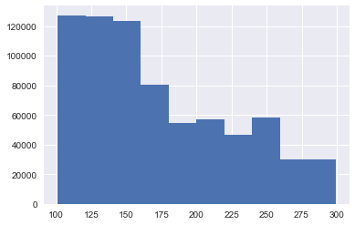

```python
df_q1.loc[((df_q1['price']>100)&(df_q1['price']<300)), 'price'].hist()
```

```python
price_ym = groupby_ym.mean().unstack()
```

```python
price_ym.index
```

```
Index(['2016-01', '2016-02', '2016-03', '2016-04', '2016-05', '2016-06',
       '2016-07', '2016-08', '2016-09', '2016-10', '2016-11', '2016-12',
       '2017-01', '2017-02', '2017-03', '2017-04', '2017-05', '2017-06',
       '2017-07', '2017-08', '2017-09'],
      dtype='object', name='year_month')
```

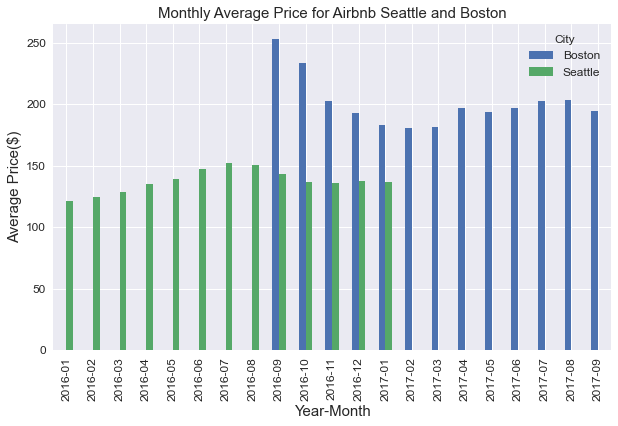

```python
price_ym.plot(kind='bar', figsize=(10,6), fontsize=12)
plt.legend(labels=['Boston', 'Seattle'], fontsize=12, title='City', title_fontsize=12)
plt.title('Monthly Average Price for Airbnb Seattle and Boston', fontsize=15)
plt.ylabel('Average Price($)', fontsize=15)
plt.xlabel('Year-Month', fontsize=15)
plt.xticks(range(0,len(price_ym.index)), price_ym.index, rotation='vertical');
```

```python
groupby_nbh = df_q1.groupby(['city','neighbourhood_cleansed'])['price']
groupby_nbh.describe()
```

| city | neighbourhood_cleansed | count | mean | std | min | 25% | 50% | 75% | max |
| --- | --- | --- | --- | --- | --- | --- | --- | --- | --- |
| boston | Allston | 34293.00000 | 131.20033 | 174.19946 | 11.00000 | 67.00000 | 90.00000 | 135.00000 | 2895.00000 |
|  | Back Bay | 57070.00000 | 284.63327 | 151.32392 | 29.00000 | 179.00000 | 251.00000 | 350.00000 | 2088.00000 |
|  | Bay Village | 5732.00000 | 307.26867 | 145.08236 | 99.00000 | 167.00000 | 294.00000 | 500.00000 | 686.00000 |
|  | Beacon Hill | 31753.00000 | 260.17290 | 229.11435 | 71.00000 | 145.00000 | 179.00000 | 274.00000 | 3314.00000 |
|  | Brighton | 31199.00000 | 137.69528 | 127.38067 | 33.00000 | 70.00000 | 99.00000 | 155.00000 | 999.00000 |
|  | Charlestown | 21272.00000 | 201.74041 | 172.61850 | 36.00000 | 75.00000 | 175.00000 | 235.00000 | 1587.00000 |
|  | Chinatown | 13037.00000 | 315.75362 | 128.36317 | 80.00000 | 239.00000 | 308.00000 | 399.00000 | 1027.00000 |
|  | Dorchester | 63587.00000 | 88.58671 | 60.02233 | 22.00000 | 56.00000 | 70.00000 | 100.00000 | 789.00000 |
|  | Downtown | 31243.00000 | 272.50456 | 144.05650 | 60.00000 | 175.00000 | 249.00000 | 329.00000 | 3000.00000 |
|  | East Boston | 29291.00000 | 137.51412 | 77.92946 | 35.00000 | 80.00000 | 110.00000 | 175.00000 | 529.00000 |
|  | Fenway | 43363.00000 | 287.44104 | 356.67601 | 45.00000 | 150.00000 | 249.00000 | 349.00000 | 4000.00000 |
|  | Hyde Park | 5732.00000 | 68.84927 | 36.55933 | 29.00000 | 50.00000 | 60.00000 | 75.00000 | 800.00000 |
|  | Jamaica Plain | 61742.00000 | 154.37825 | 119.36869 | 20.00000 | 77.00000 | 114.00000 | 185.00000 | 7163.00000 |
|  | Leather District | 725.00000 | 344.68276 | 79.22516 | 245.00000 | 245.00000 | 390.00000 | 390.00000 | 550.00000 |
|  | Longwood Medical Area | 1690.00000 | 119.97515 | 84.48340 | 60.00000 | 70.00000 | 75.00000 | 149.00000 | 409.00000 |
|  | Mattapan | 6702.00000 | 78.54685 | 44.30383 | 30.00000 | 50.00000 | 69.00000 | 95.00000 | 330.00000 |
|  | Mission Hill | 16138.00000 | 152.69209 | 118.79632 | 20.00000 | 75.00000 | 100.00000 | 239.00000 | 686.00000 |
|  | North End | 23581.00000 | 228.12832 | 124.25978 | 35.00000 | 165.00000 | 199.00000 | 250.00000 | 1500.00000 |
|  | Roslindale | 13541.00000 | 95.09962 | 53.95368 | 40.00000 | 60.00000 | 75.00000 | 115.00000 | 400.00000 |
|  | Roxbury | 29756.00000 | 162.66864 | 153.75301 | 20.00000 | 65.00000 | 100.00000 | 195.00000 | 1984.00000 |
|  | South Boston | 32981.00000 | 213.37237 | 157.80647 | 45.00000 | 106.00000 | 160.00000 | 259.00000 | 2262.00000 |
|  | South Boston Waterfront | 13377.00000 | 322.20199 | 160.32073 | 75.00000 | 200.00000 | 259.00000 | 399.00000 | 1250.00000 |
|  | South End | 54071.00000 | 234.06434 | 173.29866 | 59.00000 | 150.00000 | 196.00000 | 265.00000 | 2000.00000 |
|  | West End | 10880.00000 | 314.02399 | 122.37628 | 110.00000 | 228.00000 | 299.00000 | 369.00000 | 982.00000 |
|  | West Roxbury | 10281.00000 | 116.50092 | 87.04912 | 45.00000 | 65.00000 | 80.00000 | 137.00000 | 800.00000 |
| seattle | Adams | 15743.00000 | 130.67871 | 85.57958 | 25.00000 | 70.00000 | 100.00000 | 150.00000 | 794.00000 |
|  | Alki | 11255.00000 | 187.14554 | 104.66760 | 42.00000 | 100.00000 | 150.00000 | 250.00000 | 525.00000 |
|  | Arbor Heights | 1390.00000 | 139.92806 | 81.39710 | 54.00000 | 54.00000 | 100.00000 | 225.00000 | 250.00000 |
|  | Atlantic | 11787.00000 | 122.85671 | 68.23025 | 30.00000 | 74.00000 | 110.00000 | 149.00000 | 564.00000 |
|  | Belltown | 53320.00000 | 201.47284 | 125.75985 | 12.00000 | 125.00000 | 165.00000 | 245.00000 | 939.00000 |

[output cut: 82 more lines]

```python
#use neighbourhood_cleansed for Boston data
boston_nbh = groupby_nbh.mean().to_frame().loc['boston'].sort_values(by='price', ascending=False)
```

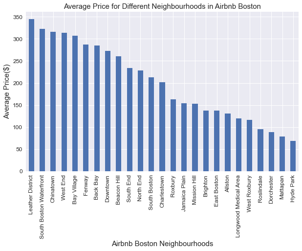

```python
boston_nbh.plot(kind='bar', figsize=(10,6), fontsize=12, legend=False)
plt.title('Average Price for Different Neighbourhoods in Airbnb Boston', fontsize=15)
plt.ylabel('Average Price($)', fontsize=15)
plt.xlabel('Airbnb Boston Neighbourhoods', fontsize=15);
```

```python
#use neighbourhood_group_cleansed for Seattle data
seattle_nbh = df_q1.groupby(['city','neighbourhood_group_cleansed'])['price'].mean().to_frame().loc['seattle'].sort_values(by='price', ascending=False)
```

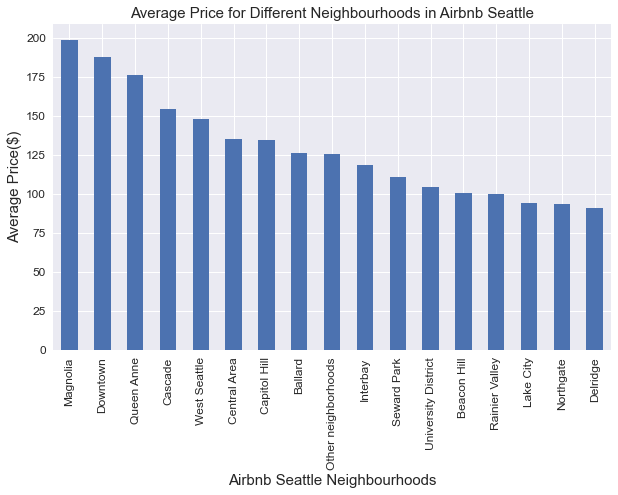

```python
seattle_nbh.plot(kind='bar', figsize=(10,6), fontsize=12, legend=False)
plt.title('Average Price for Different Neighbourhoods in Airbnb Seattle', fontsize=15)
plt.ylabel('Average Price($)', fontsize=15)
plt.xlabel('Airbnb Seattle Neighbourhoods', fontsize=15);
```

##### Question 2: How do different features affect prices in Airbnb listings?

```python
df_listing_clean.head()
```

|  | id | listing_url | name | summary | space | description | notes | transit | thumbnail_url | medium_url | picture_url | xl_picture_url | host_id | host_url | host_name | host_since | host_location | host_about | host_response_time | host_response_rate | host_acceptance_rate | host_is_superhost | host_thumbnail_url | host_picture_url | host_neighbourhood | host_listings_count | host_total_listings_count | host_verifications | host_has_profile_pic | … |
| --- | --- | --- | --- | --- | --- | --- | --- | --- | --- | --- | --- | --- | --- | --- | --- | --- | --- | --- | --- | --- | --- | --- | --- | --- | --- | --- | --- | --- | --- | --- |
| 0 | 12147973 | https://www.airbnb.com/rooms/12147973 | Sunny Bungalow in the City | Cozy, sunny, family home. Master bedroom high... | The house has an open and cozy feel at the sam... | Cozy, sunny, family home. Master bedroom high... | NaN | The bus stop is 2 blocks away, and frequent. B... | https://a2.muscache.com/im/pictures/c0842db1-e... | https://a2.muscache.com/im/pictures/c0842db1-e... | https://a2.muscache.com/im/pictures/c0842db1-e... | https://a2.muscache.com/im/pictures/c0842db1-e... | 31303940 | https://www.airbnb.com/users/show/31303940 | Virginia | 2015-04-15 | Boston, Massachusetts, United States | We are country and city connecting in our deck... | NaN | NaN | NaN | False | https://a2.muscache.com/im/pictures/5936fef0-b... | https://a2.muscache.com/im/pictures/5936fef0-b... | Roslindale | 1.00000 | 1.00000 | ['email', 'phone', 'facebook', 'reviews'] | True | … |
| 1 | 3075044 | https://www.airbnb.com/rooms/3075044 | Charming room in pet friendly apt | Charming and quiet room in a second floor 1910... | Small but cozy and quite room with a full size... | Charming and quiet room in a second floor 1910... | If you don't have a US cell phone, you can tex... | Plenty of safe street parking. Bus stops a few... | https://a1.muscache.com/im/pictures/39327812/d... | https://a1.muscache.com/im/pictures/39327812/d... | https://a1.muscache.com/im/pictures/39327812/d... | https://a1.muscache.com/im/pictures/39327812/d... | 2572247 | https://www.airbnb.com/users/show/2572247 | Andrea | 2012-06-07 | Boston, Massachusetts, United States | I live in Boston and I like to travel and have... | within an hour | 1.00000 | 1.00000 | False | https://a2.muscache.com/im/users/2572247/profi... | https://a2.muscache.com/im/users/2572247/profi... | Roslindale | 1.00000 | 1.00000 | ['email', 'phone', 'facebook', 'linkedin', 'am... | True | … |
| 2 | 6976 | https://www.airbnb.com/rooms/6976 | Mexican Folk Art Haven in Boston | Come stay with a friendly, middle-aged guy in ... | Come stay with a friendly, middle-aged guy in ... | Come stay with a friendly, middle-aged guy in ... | I am in a scenic part of Boston with a couple ... | PUBLIC TRANSPORTATION: From the house, quick p... | https://a2.muscache.com/im/pictures/6ae8335d-9... | https://a2.muscache.com/im/pictures/6ae8335d-9... | https://a2.muscache.com/im/pictures/6ae8335d-9... | https://a2.muscache.com/im/pictures/6ae8335d-9... | 16701 | https://www.airbnb.com/users/show/16701 | Phil | 2009-05-11 | Boston, Massachusetts, United States | I am a middle-aged, single male with a wide ra... | within a few hours | 1.00000 | 0.88000 | True | https://a2.muscache.com/im/users/16701/profile... | https://a2.muscache.com/im/users/16701/profile... | Roslindale | 1.00000 | 1.00000 | ['email', 'phone', 'reviews', 'jumio'] | True | … |
| 3 | 1436513 | https://www.airbnb.com/rooms/1436513 | Spacious Sunny Bedroom Suite in Historic Home | Come experience the comforts of home away from... | Most places you find in Boston are small howev... | Come experience the comforts of home away from... | Please be mindful of the property as it is old... | There are buses that stop right in front of th... | https://a2.muscache.com/im/pictures/39764190-1... | https://a2.muscache.com/im/pictures/39764190-1... | https://a2.muscache.com/im/pictures/39764190-1... | https://a2.muscache.com/im/pictures/39764190-1... | 6031442 | https://www.airbnb.com/users/show/6031442 | Meghna | 2013-04-21 | Boston, Massachusetts, United States | My husband and I live on the property. He’s a... | within a few hours | 1.00000 | 0.50000 | False | https://a2.muscache.com/im/pictures/5d430cde-7... | https://a2.muscache.com/im/pictures/5d430cde-7... | NaN | 1.00000 | 1.00000 | ['email', 'phone', 'reviews'] | True | … |
| 4 | 7651065 | https://www.airbnb.com/rooms/7651065 | Come Home to Boston | My comfy, clean and relaxing home is one block... | Clean, attractive, private room, one block fro... | My comfy, clean and relaxing home is one block... | I have one roommate who lives on the lower lev... | From Logan Airport and South Station you have... | https://a1.muscache.com/im/pictures/97154760/8... | https://a1.muscache.com/im/pictures/97154760/8... | https://a1.muscache.com/im/pictures/97154760/8... | https://a1.muscache.com/im/pictures/97154760/8... | 15396970 | https://www.airbnb.com/users/show/15396970 | Linda | 2014-05-11 | Boston, Massachusetts, United States | I work full time for a public school district.... | within an hour | 1.00000 | 1.00000 | True | https://a0.muscache.com/im/users/15396970/prof... | https://a0.muscache.com/im/users/15396970/prof... | Roslindale | 1.00000 | 1.00000 | ['email', 'phone', 'reviews', 'kba'] | True | … |

First, I will take a look at the numerical values.

```python
df_listing_clean.describe()
```

|  | id | host_id | host_response_rate | host_acceptance_rate | host_listings_count | host_total_listings_count | latitude | longitude | price | weekly_price | monthly_price | security_deposit | cleaning_fee | extra_people | accommodates | bathrooms | bedrooms | beds | guests_included | minimum_nights | maximum_nights | calculated_host_listings_count | availability_30 | availability_60 | availability_90 | availability_365 | number_of_reviews | review_scores_rating | review_scores_accuracy | … |
| --- | --- | --- | --- | --- | --- | --- | --- | --- | --- | --- | --- | --- | --- | --- | --- | --- | --- | --- | --- | --- | --- | --- | --- | --- | --- | --- | --- | --- | --- | --- |
| count | 7403.00000 | 7403.00000 | 6409.00000 | 6159.00000 | 7401.00000 | 7401.00000 | 7403.00000 | 7403.00000 | 7403.00000 | 2901.00000 | 2405.00000 | 3208.00000 | 5266.00000 | 7403.00000 | 7403.00000 | 7373.00000 | 7387.00000 | 7393.00000 | 7403.00000 | 7403.00000 | 7403.00000 | 7403.00000 | 7403.00000 | 7403.00000 | 7403.00000 | 7403.00000 | 7403.00000 | 5943.00000 | 5922.00000 | … |
| mean | 6950001.47724 | 20210534.86600 | 0.94936 | 0.91982 | 32.22254 | 32.22254 | 45.06773 | -97.51545 | 150.22788 | 829.65667 | 3011.64823 | 303.12531 | 64.84922 | 10.77347 | 3.20019 | 1.24115 | 1.28266 | 1.67429 | 1.55505 | 2.75767 | 14313.36944 | 7.68607 | 12.84614 | 29.55977 | 48.62758 | 213.08915 | 20.68405 | 93.31600 | 9.54086 | … |
| std | 4052396.78067 | 19623093.34622 | 0.12187 | 0.17429 | 123.58516 | 123.58516 | 2.64357 | 25.61320 | 124.01968 | 577.06278 | 2290.11509 | 296.68987 | 50.11256 | 18.35290 | 1.89017 | 0.54941 | 0.82325 | 1.08136 | 1.20076 | 13.24383 | 1162232.12958 | 21.46587 | 12.06996 | 23.83940 | 35.01331 | 138.34284 | 36.73302 | 8.20745 | 0.82178 | … |
| min | 3335.00000 | 4193.00000 | 0.00000 | 0.00000 | 0.00000 | 0.00000 | 42.23594 | -122.41722 | 10.00000 | 80.00000 | 500.00000 | 95.00000 | 5.00000 | 0.00000 | 1.00000 | 0.00000 | 0.00000 | 0.00000 | 0.00000 | 1.00000 | 1.00000 | 1.00000 | 0.00000 | 0.00000 | 0.00000 | 0.00000 | 0.00000 | 20.00000 | 2.00000 | … |
| 25% | 3864099.50000 | 4343163.50000 | 0.97000 | 0.94000 | 1.00000 | 1.00000 | 42.34567 | -122.33084 | 79.00000 | 458.00000 | 1595.00000 | 149.75000 | 25.00000 | 0.00000 | 2.00000 | 1.00000 | 1.00000 | 1.00000 | 1.00000 | 1.00000 | 95.50000 | 1.00000 | 0.00000 | 1.00000 | 7.00000 | 77.00000 | 1.00000 | 91.00000 | 9.00000 | … |
| 50% | 7035240.00000 | 14486505.00000 | 1.00000 | 1.00000 | 1.00000 | 1.00000 | 47.54291 | -122.27642 | 120.00000 | 660.00000 | 2400.00000 | 250.00000 | 50.00000 | 0.00000 | 2.00000 | 1.00000 | 1.00000 | 1.00000 | 1.00000 | 2.00000 | 1125.00000 | 1.00000 | 10.00000 | 31.00000 | 56.00000 | 259.00000 | 7.00000 | 96.00000 | 10.00000 | … |
| 75% | 9500804.00000 | 30283594.00000 | 1.00000 | 1.00000 | 4.00000 | 4.00000 | 47.62446 | -71.07952 | 190.00000 | 1000.00000 | 3500.00000 | 400.00000 | 95.00000 | 20.00000 | 4.00000 | 1.00000 | 2.00000 | 2.00000 | 2.00000 | 3.00000 | 1125.00000 | 3.00000 | 26.00000 | 55.00000 | 84.00000 | 347.00000 | 23.00000 | 99.00000 | 10.00000 | … |
| max | 14933461.00000 | 93854106.00000 | 1.00000 | 1.00000 | 749.00000 | 749.00000 | 47.73336 | -71.00010 | 4000.00000 | 6300.00000 | 40000.00000 | 5000.00000 | 300.00000 | 300.00000 | 16.00000 | 8.00000 | 7.00000 | 16.00000 | 15.00000 | 1000.00000 | 99999999.00000 | 136.00000 | 30.00000 | 60.00000 | 90.00000 | 365.00000 | 474.00000 | 100.00000 | 10.00000 | … |

```python
listing_num = df_listing_clean[['price', 'host_response_rate', 'host_acceptance_rate', 'host_total_listings_count',
                                'latitude', 'longitude', 'security_deposit', 'cleaning_fee', 'extra_people',
                                'accommodates', 'bathrooms', 'bedrooms', 'beds', 'guests_included', 'minimum_nights', 'maximum_nights',
                                'availability_30', 'availability_365', 'number_of_reviews', 'review_scores_value']]
```

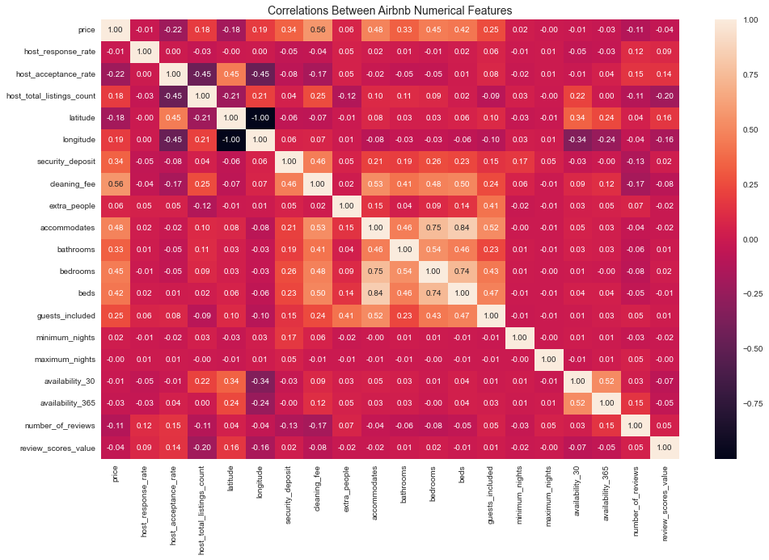

```python
plt.figure(figsize=(16,10))
sns.heatmap(listing_num.corr(), annot=True, fmt='.2f')
plt.title('Correlations Between Airbnb Numerical Features', fontsize=14)
plt.show();
```

From the absolute values, **security_deposit**, **cleaning_fee**, **accommodates**, **bathrooms**, **beds** have relatively stronger correlations with listing price.

Then I will take a look at the relationships between listing price with other categorical values other than neighborhood.

```python
df_listing_clean.select_dtypes(include=['object']).columns
```

```
Index(['listing_url', 'name', 'summary', 'space', 'description', 'notes',
       'transit', 'thumbnail_url', 'medium_url', 'picture_url',
       'xl_picture_url', 'host_url', 'host_name', 'host_since',
       'host_location', 'host_about', 'host_response_time',
       'host_is_superhost', 'host_thumbnail_url', 'host_picture_url',
       'host_neighbourhood', 'host_verifications', 'host_has_profile_pic',
       'host_identity_verified', 'neighborhood_overview', 'street',
       'neighbourhood_group_cleansed', 'neighbourhood_cleansed', 'state',
       'zipcode', 'market', 'country_code', 'country', 'property_type',
       'room_type', 'bed_type', 'amenities', 'cancellation_policy'],
      dtype='object')
```

```python
listing_cat = df_listing_clean[['price', 'host_response_time', 'host_is_superhost', 'property_type', 'room_type', 'bed_type', 'cancellation_policy']]
```

```python
listing_cat.info()
```

```
<class 'pandas.core.frame.DataFrame'>
Int64Index: 7403 entries, 0 to 3817
Data columns (total 7 columns):
 #   Column               Non-Null Count  Dtype
---  ------               --------------  -----
 0   price                7403 non-null   float64
 1   host_response_time   6409 non-null   object
 2   host_is_superhost    7401 non-null   object
 3   property_type        7399 non-null   object
 4   room_type            7403 non-null   object
 5   bed_type             7403 non-null   object
 6   cancellation_policy  7403 non-null   object
dtypes: float64(1), object(6)
memory usage: 462.7+ KB
```

[figure not shown]

```python
plt.figure(figsize=(12, 15))
plt.subplots_adjust(hspace=0.8)
plt.suptitle('Average Price for Airbnb Categorical Features', fontsize=14)
cat_index = ['host_response_time', 'host_is_superhost', 'property_type', 'room_type', 'bed_type', 'cancellation_policy']
for n, cat in enumerate(cat_index):
    ax = plt.subplot(3, 2, n + 1)
    listing_cat.groupby(cat)['price'].mean().plot(kind='bar',fontsize=12, legend=False)
    ax.set_ylabel('Average Price($)')
```

From the graph, I can conclude that **property_type**, **room_type**, **bed_type**, **cancellation_policy**, **host_response_time** make a difference for Airbnb listing prices.

##### Question 3: How well can we predict the price with a Linear Regression model?

I will select features that are most relevant to listing prices based on the second question, and fit a linear regression model for Airbnb Seattle and Airbnb Boston respectively.

```python
#feature selection
boston_var = ['security_deposit', 'cleaning_fee', 'accommodates', 'bathrooms', 'beds',
             'property_type', 'room_type', 'bed_type', 'cancellation_policy', 'host_response_time',
              'price']
seattle_var = ['security_deposit', 'cleaning_fee', 'accommodates', 'bathrooms', 'beds',
             'property_type', 'room_type', 'bed_type', 'cancellation_policy', 'host_response_time',
              'price']
```

```python
#deal with missing values
boston_df = df_listing_clean[df_listing_clean['market']=='boston'][boston_var]
seattle_df = df_listing_clean[df_listing_clean['market']=='seattle'][seattle_var]
display(boston_df.info())
display(seattle_df.info())
```

```
<class 'pandas.core.frame.DataFrame'>
Int64Index: 3585 entries, 0 to 3584
Data columns (total 11 columns):
 #   Column               Non-Null Count  Dtype
---  ------               --------------  -----
 0   security_deposit     1342 non-null   float64
 1   cleaning_fee         2478 non-null   float64
 2   accommodates         3585 non-null   int64
 3   bathrooms            3571 non-null   float64
 4   beds                 3576 non-null   float64
 5   property_type        3582 non-null   object
 6   room_type            3585 non-null   object
 7   bed_type             3585 non-null   object
 8   cancellation_policy  3585 non-null   object
 9   host_response_time   3114 non-null   object
 10  price                3585 non-null   float64
dtypes: float64(5), int64(1), object(5)
memory usage: 336.1+ KB
```

```
None
```

```
<class 'pandas.core.frame.DataFrame'>
Int64Index: 3818 entries, 0 to 3817
Data columns (total 11 columns):
 #   Column               Non-Null Count  Dtype
---  ------               --------------  -----
 0   security_deposit     1866 non-null   float64
 1   cleaning_fee         2788 non-null   float64
 2   accommodates         3818 non-null   int64
 3   bathrooms            3802 non-null   float64
 4   beds                 3817 non-null   float64
 5   property_type        3817 non-null   object
 6   room_type            3818 non-null   object
 7   bed_type             3818 non-null   object
 8   cancellation_policy  3818 non-null   object
 9   host_response_time   3295 non-null   object
 10  price                3818 non-null   float64
dtypes: float64(5), int64(1), object(5)
memory usage: 357.9+ KB
```

```
None
```

`Deal with Missing Values`:

```python
boston_df.drop('security_deposit', axis=1, inplace=True)
seattle_df.drop('security_deposit', axis=1, inplace=True)
```

```python
display(seattle_df.describe())
display(boston_df.describe())
```

|  | cleaning_fee | accommodates | bathrooms | beds | price |
| --- | --- | --- | --- | --- | --- |
| count | 2788.00000 | 3818.00000 | 3802.00000 | 3817.00000 | 3818.00000 |
| mean | 61.71090 | 3.34940 | 1.25947 | 1.73539 | 127.97617 |
| std | 48.83034 | 1.97760 | 0.59037 | 1.13948 | 90.25002 |
| min | 5.00000 | 1.00000 | 0.00000 | 1.00000 | 20.00000 |
| 25% | 25.00000 | 2.00000 | 1.00000 | 1.00000 | 75.00000 |
| 50% | 50.00000 | 3.00000 | 1.00000 | 1.00000 | 100.00000 |
| 75% | 83.00000 | 4.00000 | 1.00000 | 2.00000 | 150.00000 |
| max | 300.00000 | 16.00000 | 8.00000 | 15.00000 | 1000.00000 |

|  | cleaning_fee | accommodates | bathrooms | beds | price |
| --- | --- | --- | --- | --- | --- |
| count | 2478.00000 | 3585.00000 | 3571.00000 | 3576.00000 | 3585.00000 |
| mean | 68.38015 | 3.04128 | 1.22165 | 1.60906 | 173.92580 |
| std | 51.29783 | 1.77893 | 0.50149 | 1.01174 | 148.33132 |
| min | 5.00000 | 1.00000 | 0.00000 | 0.00000 | 10.00000 |
| 25% | 25.00000 | 2.00000 | 1.00000 | 1.00000 | 85.00000 |
| 50% | 50.00000 | 2.00000 | 1.00000 | 1.00000 | 150.00000 |
| 75% | 100.00000 | 4.00000 | 1.00000 | 2.00000 | 220.00000 |
| max | 300.00000 | 16.00000 | 6.00000 | 16.00000 | 4000.00000 |

```python
seattle_df['cleaning_fee'] = seattle_df['cleaning_fee'].fillna(seattle_df['cleaning_fee'].mean())
boston_df['cleaning_fee'] = boston_df['cleaning_fee'].fillna(boston_df['cleaning_fee'].mean())
```

```python
seattle_df.dropna(how='any', inplace=True)
boston_df.dropna(how='any', inplace=True)
```

```python
display(seattle_df.describe())
display(boston_df.describe())
```

|  | cleaning_fee | accommodates | bathrooms | beds | price |
| --- | --- | --- | --- | --- | --- |
| count | 3281.00000 | 3281.00000 | 3281.00000 | 3281.00000 | 3281.00000 |
| mean | 61.43723 | 3.38708 | 1.25922 | 1.75099 | 124.62847 |
| std | 42.30834 | 1.99652 | 0.59258 | 1.14864 | 87.91954 |
| min | 5.00000 | 1.00000 | 0.00000 | 1.00000 | 22.00000 |
| 25% | 35.00000 | 2.00000 | 1.00000 | 1.00000 | 72.00000 |
| 50% | 61.71090 | 3.00000 | 1.00000 | 1.00000 | 100.00000 |
| 75% | 65.00000 | 4.00000 | 1.00000 | 2.00000 | 150.00000 |
| max | 300.00000 | 16.00000 | 8.00000 | 15.00000 | 999.00000 |

|  | cleaning_fee | accommodates | bathrooms | beds | price |
| --- | --- | --- | --- | --- | --- |
| count | 3098.00000 | 3098.00000 | 3098.00000 | 3098.00000 | 3098.00000 |
| mean | 69.63984 | 3.09425 | 1.22934 | 1.62944 | 171.46320 |
| std | 44.18927 | 1.81822 | 0.51403 | 1.04138 | 116.75029 |
| min | 5.00000 | 1.00000 | 0.00000 | 0.00000 | 10.00000 |
| 25% | 40.00000 | 2.00000 | 1.00000 | 1.00000 | 85.00000 |
| 50% | 68.38015 | 2.00000 | 1.00000 | 1.00000 | 150.00000 |
| 75% | 90.00000 | 4.00000 | 1.00000 | 2.00000 | 222.25000 |
| max | 300.00000 | 16.00000 | 6.00000 | 16.00000 | 1345.00000 |

Below is a function used to create `dummy variables` for dataframe with categorical values. I learnt it from the [Udacity Data Sicence Course](https://www.udacity.com/course/data-scientist-nanodegree--nd025).

```python
#create dummy variables
def create_dummy_df(df, cat_cols, dummy_na):
    '''
    INPUT:
    df - pandas dataframe with categorical variables you want to dummy
    cat_cols - list of strings that are associated with names of the categorical columns
    dummy_na - Bool holding whether you want to dummy NA vals of categorical columns or not

    OUTPUT:
    df - a new dataframe that has the following characteristics:
            1. contains all columns that were not specified as categorical
            2. removes all the original columns in cat_cols
            3. dummy columns for each of the categorical columns in cat_cols
            4. if dummy_na is True - it also contains dummy columns for the NaN values
            5. Use a prefix of the column name with an underscore (_) for separating
    '''
    for col in cat_cols:
        try:
            dummy_df = pd.get_dummies(df[col], dummy_na=dummy_na, prefix=col, prefix_sep='_', drop_first=True)
            df.drop(col, axis=1, inplace=True)
            df = pd.concat([df, dummy_df], axis=1)
        except:
            continue
    return df
```

```python
seattle_df_mol = create_dummy_df(seattle_df,
                             ['property_type','room_type', 'bed_type', 'cancellation_policy','host_response_time'],
                             dummy_na=False)
boston_df_mol = create_dummy_df(boston_df,
                             ['property_type','room_type', 'bed_type', 'cancellation_policy','host_response_time'],
                             dummy_na=False)
```

```python
display(seattle_df_mol.head())
display(boston_df_mol.head())
```

|  | cleaning_fee | accommodates | bathrooms | beds | price | room_type_Private room | room_type_Shared room | bed_type_Couch | bed_type_Futon | bed_type_Pull-out Sofa | bed_type_Real Bed | cancellation_policy_moderate | cancellation_policy_strict | host_response_time_within a day | host_response_time_within a few hours | host_response_time_within an hour |
| --- | --- | --- | --- | --- | --- | --- | --- | --- | --- | --- | --- | --- | --- | --- | --- | --- |
| 0 | 61.71090 | 4 | 1.00000 | 1.00000 | 85.00000 | 0 | 0 | 0 | 0 | 0 | 1 | 1 | 0 | 0 | 1 | 0 |
| 1 | 40.00000 | 4 | 1.00000 | 1.00000 | 150.00000 | 0 | 0 | 0 | 0 | 0 | 1 | 0 | 1 | 0 | 0 | 1 |
| 2 | 300.00000 | 11 | 4.50000 | 7.00000 | 975.00000 | 0 | 0 | 0 | 0 | 0 | 1 | 0 | 1 | 0 | 1 | 0 |
| 4 | 125.00000 | 6 | 2.00000 | 3.00000 | 450.00000 | 0 | 0 | 0 | 0 | 0 | 1 | 0 | 1 | 0 | 0 | 1 |
| 6 | 61.71090 | 2 | 1.00000 | 1.00000 | 80.00000 | 1 | 0 | 0 | 0 | 0 | 1 | 1 | 0 | 0 | 0 | 1 |

|  | cleaning_fee | accommodates | bathrooms | beds | price | room_type_Private room | room_type_Shared room | bed_type_Couch | bed_type_Futon | bed_type_Pull-out Sofa | bed_type_Real Bed | cancellation_policy_moderate | cancellation_policy_strict | cancellation_policy_super_strict_30 | host_response_time_within a day | host_response_time_within a few hours | host_response_time_within an hour |
| --- | --- | --- | --- | --- | --- | --- | --- | --- | --- | --- | --- | --- | --- | --- | --- | --- | --- |
| 1 | 10.00000 | 2 | 1.00000 | 1.00000 | 65.00000 | 1 | 0 | 0 | 0 | 0 | 1 | 1 | 0 | 0 | 0 | 0 | 1 |
| 2 | 68.38015 | 2 | 1.00000 | 1.00000 | 65.00000 | 1 | 0 | 0 | 0 | 0 | 1 | 1 | 0 | 0 | 0 | 1 | 0 |
| 3 | 50.00000 | 4 | 1.00000 | 2.00000 | 75.00000 | 1 | 0 | 0 | 0 | 0 | 1 | 1 | 0 | 0 | 0 | 1 | 0 |
| 4 | 15.00000 | 2 | 1.50000 | 2.00000 | 79.00000 | 1 | 0 | 0 | 0 | 0 | 1 | 0 | 0 | 0 | 0 | 0 | 1 |
| 5 | 30.00000 | 2 | 1.00000 | 1.00000 | 75.00000 | 1 | 0 | 0 | 0 | 0 | 1 | 0 | 0 | 0 | 0 | 1 | 0 |

```python
#split data into X matrix and a resonse vector y
boston_X = boston_df_mol.drop('price', axis=1)
boston_y = boston_df_mol['price']

seattle_X = seattle_df_mol.drop('price', axis=1)
seattle_y = seattle_df_mol['price']
```

```python
#create training and test sets
boston_X_train, boston_X_test, boston_y_train, boston_y_test = train_test_split(boston_X,
                                                                                boston_y,
                                                                                test_size=0.3,
                                                                                random_state=32)

seattle_X_train, seattle_X_test, seattle_y_train, seattle_y_test = train_test_split(seattle_X,
                                                                                seattle_y,
                                                                                test_size=0.3,
                                                                                random_state=32)
```

```python
#instantiate a LinearRegression model with normalized data and fit the model to training data
boston_lm_model = LinearRegression(normalize=True)
boston_lm_model.fit(boston_X_train, boston_y_train)
```

```
LinearRegression(normalize=True)
```

```python
seattle_lm_model = LinearRegression(normalize=True)
seattle_lm_model.fit(seattle_X_train, seattle_y_train)
```

```
LinearRegression(normalize=True)
```

```python
#predict the response for the training data and the test data
boston_y_train_preds = boston_lm_model.predict(boston_X_train)
boston_y_test_preds = boston_lm_model.predict(boston_X_test)
```

```python
seattle_y_train_preds = seattle_lm_model.predict(seattle_X_train)
seattle_y_test_preds = seattle_lm_model.predict(seattle_X_test)
```

```python
#obtain an rsquared value for both the training and test data
boston_test_score = r2_score(boston_y_test, boston_y_test_preds)
boston_train_score = r2_score(boston_y_train, boston_y_train_preds)
```

```python
seattle_test_score = r2_score(seattle_y_test, seattle_y_test_preds)
seattle_train_score = r2_score(seattle_y_train, seattle_y_train_preds)
```

```python
print(f'{boston_train_score:.3f}',  f'{boston_test_score:.3f}')
```

```
0.496 0.434
```

```python
print(f'{seattle_train_score:.3f}', f'{seattle_test_score:.3f}')
```

```
0.588 0.508
```

`Model Results`:

```python
"The r-squared score for Airbnb Boston training dataset is {:.2f} on {} values" \
.format(boston_train_score, len(boston_y_train))
```

```
'The r-squared score for Airbnb Boston training dataset is 0.50 on 2168 values'
```

```python
"The r-squared score for Airbnb Boston test dataset is {:.2f} on {} values" \
.format(boston_test_score, len(boston_y_test))
```

```
'The r-squared score for Airbnb Boston test dataset is 0.43 on 930 values'
```

```python
"The r-squared score for Airbnb Seattle training dataset is {:.2f} on {} values" \
.format(seattle_train_score, len(seattle_y_train))
```

```
'The r-squared score for Airbnb Seattle training dataset is 0.59 on 2296 values'
```

```python
"The r-squared score for Airbnb Seattle test dataset is {:.2f} on {} values" \
.format(seattle_test_score, len(seattle_y_test))
```

```
'The r-squared score for Airbnb Seattle test dataset is 0.51 on 985 values'
```

The r-square scores for Airbnb Boston and Seattle test datasets are around 0.5, which is unsatisfactory, I would suggest trying some other machine learning models. However, the r-square score for training and testing datasets are similar, suggesting the model is not overfitting.

#### Part IV: Deployment & Communication

In `Part IV` of the Airbnb Project, I will create a Github repository to share my code and create a blog post to share the insights about the three business questions.